# Regression Method/CI Analysis

Kayleigh Ryherd

10/26/2016

# 15/70 Confidence Intervals

## Table of Contents

1. Linear Model with WASI Vocab
   - Group Differences
2. Linear Model with PPVT
   - Group Differences
3. Linear Model with Vocabulary Composite
   - Group Differences
4. Linear Model with Oral Comprehension
   - Group Differences
5. Robust Model with WASI Vocab
   - Group Differences
6. Robust Model with PPVT
   - Group Differences
7. Robust Model with Vocabulary Composite
   - Group Differences
8. Robust Model with Oral Comprehension
   - Group Differences
9. Group Sizes

Read in packages & data.

```r
library(fBasics)
library(caret)
library(MASS)
library(ggplot2)
library(plyr)
library(reshape2)
library(xtable)
setwd("~/Dropbox/Definition_of_PCs/RegressionDefinitionMethod")
data <- read.csv("FullData_FinalMay23_2017.csv")
data <- data[data$handedness == "right",]
data$age.beh <- as.numeric(levels(data$age.beh))[data$age.beh]
```

Define some functions.

```r
# for plotting
gg_color_hue <- function(n) {
  hues = seq(15, 375, length=n+1)
  hcl(h=hues, l=65, c=100)[1:n]
}

# CIs to z-scores
ci2z <- function(ci)
{
  qnorm(ci + (1 - ci)/2)
}
```

Choose your CIs.

```r
ci.to.use <- c(.15, .70)
ci.title <- "CIs: 15%, 70%"
```

## Linear Model with WASI Vocab

Run model, get groups.

```r
model.data.lmwv <- data[, c(1, 3, 19, 8, 7, 21, 12)]
lmwv.cc <- model.data.lmwv[complete.cases(model.data.lmwv),]
## Checking predictors, outcome
dagoTest(lmwv.cc$decoding.comp)
```

```
##
## Title:
##  D'Agostino Normality Test
##
## Test Results:
##   STATISTIC:
##     Chi2 | Omnibus: 1.2247
##     Z3  | Skewness: -1.0987
##     Z4  | Kurtosis: -0.1321
##   P VALUE:
##     Omnibus  Test: 0.5421
##     Skewness Test: 0.2719
##     Kurtosis Test: 0.8949
##
## Description:
##  Wed May 24 11:22:12 2017 by user:
```

```r
dagoTest(lmwv.cc$wasi.matr.raw)
```

```
##
## Title:
##  D'Agostino Normality Test
##
## Test Results:
##   STATISTIC:
##     Chi2 | Omnibus: 13.6018
##     Z3  | Skewness: -3.6828
##     Z4  | Kurtosis: -0.1977
##   P VALUE:
##     Omnibus  Test: 0.001113
##     Skewness Test: 0.0002307
##     Kurtosis Test: 0.8433
##
## Description:
##  Wed May 24 11:22:12 2017 by user:
```

```r
dagoTest(lmwv.cc$wasi.vocab.raw)
```

```
##
## Title:
##  D'Agostino Normality Test
##
## Test Results:
##   STATISTIC:
##     Chi2 | Omnibus: 3.6705
##     Z3  | Skewness: -0.9614
##     Z4  | Kurtosis: -1.6572
##   P VALUE:
##     Omnibus  Test: 0.1596
##     Skewness Test: 0.3363
##     Kurtosis Test: 0.09749
##
## Description:
##  Wed May 24 11:22:12 2017 by user:
```

```r
dagoTest(lmwv.cc$wj3.rcomp.raw)
```

```
##
## Title:
##  D'Agostino Normality Test
##
## Test Results:
##   STATISTIC:
##     Chi2 | Omnibus: 13.0948
##     Z3  | Skewness: -1.8765
##     Z4  | Kurtosis: -3.0941
##   P VALUE:
##     Omnibus  Test: 0.001434
##     Skewness Test: 0.06058
##     Kurtosis Test: 0.001974
##
## Description:
##  Wed May 24 11:22:12 2017 by user:
```

```r
## everything needs to be transformed except the decoding.comp, wasi vocab
vars_tf <- c("wasi.matr.raw", "wj3.rcomp.raw")
pp_md_tf <- preProcess(lmwv.cc[,vars_tf], method = c("center", "scale", "YeoJohnson"), na.remove=T)

#check the lambda values associated with the predictors
pp_md_tf$yj$wasi.matr.raw$lambda
```

```
##       Y1
## 2.671367
```

```r
pp_md_tf$yj$wj3.rcomp.raw$lambda
```

```
##       Y1
## 2.438059
```

```r
tf_data <- predict(pp_md_tf, lmwv.cc[,vars_tf])
lmwv.cc$wasi.matr.tf <- tf_data$wasi.matr.raw
lmwv.cc$wj3.rcomp.tf <- tf_data$wj3.rcomp.raw

dagoTest(lmwv.cc$wasi.matr.tf)
```

```
##
## Title:
##  D'Agostino Normality Test
##
## Test Results:
##   STATISTIC:
##     Chi2 | Omnibus: 11.5794
##     Z3  | Skewness: -0.8876
##     Z4  | Kurtosis: -3.2851
##   P VALUE:
##     Omnibus  Test: 0.003059
##     Skewness Test: 0.3748
##     Kurtosis Test: 0.00102
##
## Description:
##  Wed May 24 11:22:13 2017 by user:
```

```r
dagoTest(lmwv.cc$wj3.rcomp.tf)
```

```
##
## Title:
##  D'Agostino Normality Test
##
## Test Results:
##   STATISTIC:
##     Chi2 | Omnibus: 18.8738
##     Z3  | Skewness: -0.4659
##     Z4  | Kurtosis: -4.3193
##   P VALUE:
##     Omnibus  Test: 7.973e-05
##     Skewness Test: 0.6413
##     Kurtosis Test: 1.565e-05
##
## Description:
##  Wed May 24 11:22:13 2017 by user:
```

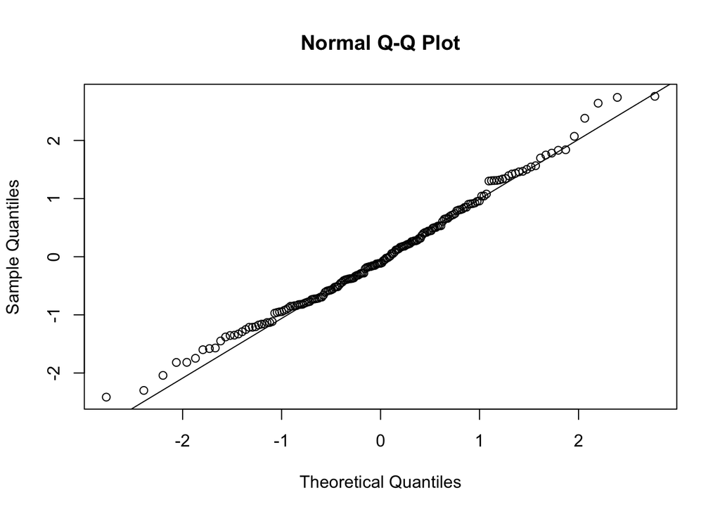

```r
# skewness has pretty much been fixed in all of them -- problem is just kurtosis

# center age
lmwv.cc$age.c <- lmwv.cc$age.beh - mean(lmwv.cc$age.beh, na.rm = TRUE)
# center/scale wasi vocab
lmwv.cc$wasi.vocab.cs <- scale(lmwv.cc$wasi.vocab.raw)
# composite has already been scaled

### Run regression
m1 <- lm(wj3.rcomp.tf ~ age.c + decoding.comp + wasi.matr.tf + wasi.vocab.cs, data = lmwv.cc)

#standardize predicted values
lmwv.cc$Pred <- predict(m1)
lmwv.cc$stdPred <- scale(lmwv.cc$Pred)

#obtained residuals
lmwv.cc$resid <- resid <- residuals(m1)
qqnorm(scale(resid)); qqline(scale(resid))
```

```r
#create the range of SD (z value) bins
my.bin <- c(range(scale(resid))+.1, ci2z(ci.to.use), -ci2z(ci.to.use))
#we could also manually specify in terms of SDs
# my.bin <- c(-3, -1, -.25, .25, 1, 3)
my.bin <- sort(my.bin)
# names for each bin specified above
grouping <- c("UPC", "NSC", "EAC", "NSC", "UGC")

lmwv.cc$CI_group <- grouping[findInterval(scale(resid), vec=my.bin, all.inside=T)]
#those with Standardized Predicted Value below -1 should be "EPC"
lmwv.cc$CI_group[lmwv.cc$stdPred < -1] <- "EPC"

### there are five groups c("EAC", "NSC", "UGC", "UPC", "EPC")
### so the argument n = 5
my.col <- gg_color_hue(n=5)

## unscale the z value for each CI, so I can add that value to intercept
unscale.ci <- my.bin[-c(1,length(my.bin))]*sd(resid)+mean(resid)

## create plot
m2 <- lm(wj3.rcomp.tf ~ stdPred, data=lmwv.cc)

p1 <- ggplot(lmwv.cc, aes(x=stdPred, y=wj3.rcomp.tf)) + geom_point(aes(color=CI_group)) +
  geom_abline(intercept = coef(m2)[1], slope = coef(m2)[2]) +
  geom_abline(intercept = coef(m2)[1] + unscale.ci[2], slope = coef(m2)[2], color=my.col[1]) +
  geom_abline(intercept = coef(m2)[1] + unscale.ci[3], slope = coef(m2)[2], color=my.col[1]) +
  geom_abline(intercept = coef(m2)[1] + unscale.ci[1], slope = coef(m2)[2], color=my.col[4]) +
  geom_abline(intercept = coef(m2)[1] + unscale.ci[4], slope = coef(m2)[2], color=my.col[3]) +
  geom_vline(xintercept = -1, lty="dotted") +
  xlab("Standardized Predicted Value")+ylab("WJ3 Reading Comprehension") +
  ggtitle(ci.title)
```

## Group Differences LM1

Linear Model with WASI vocab

```r
# take away NSC group
lmwv.cc2 <- subset(lmwv.cc, CI_group != "NSC")
lmwv.cc2$CI_group <- as.factor(lmwv.cc2$CI_group)
```

### Reading Comprehension

```r
a1 <- aov(wj3.rcomp.tf ~ CI_group, data = lmwv.cc2)
summary(a1)
```

```
##             Df Sum Sq Mean Sq F value Pr(>F)
## CI_group     3  96.02   32.01   103.4 <2e-16 ***
## Residuals   96  29.71    0.31
## ---
## Signif. codes:  0 '***' 0.001 '**' 0.01 '*' 0.05 '.' 0.1 ' ' 1
```

```r
pairwise.t.test(lmwv.cc2$wj3.rcomp.tf, lmwv.cc2$CI_group, p.adjust.method = "bonferroni")
```

```
##
##  Pairwise comparisons using t tests with pooled SD
##
## data:  lmwv.cc2$wj3.rcomp.tf and lmwv.cc2$CI_group
##
##     EAC     EPC     UGC
## EPC < 2e-16 -       -
## UGC 0.00028 < 2e-16 -
## UPC 5.2e-09 0.01862 < 2e-16
##
## P value adjustment method: bonferroni
```

```r
aggregate(lmwv.cc2$wj3.rcomp.tf, list(lmwv.cc2$CI_group), mean)
```

```
##   Group.1          x
## 1     EAC  0.4578409
## 2     EPC -1.2079554
## 3     UGC  1.1839183
## 4     UPC -0.7395147
```

### Age

```r
a1 <- aov(age.c ~ CI_group, data = lmwv.cc2)
summary(a1)
```

```
##             Df Sum Sq Mean Sq F value   Pr(>F)
## CI_group     3  167.1   55.69   8.857 3.06e-05 ***
## Residuals   96  603.6    6.29
## ---
## Signif. codes:  0 '***' 0.001 '**' 0.01 '*' 0.05 '.' 0.1 ' ' 1
```

```r
pairwise.t.test(lmwv.cc2$age.c, lmwv.cc2$CI_group, p.adjust.method = "bonferroni")
```

```
##
##  Pairwise comparisons using t tests with pooled SD
##
## data:  lmwv.cc2$age.c and lmwv.cc2$CI_group
##
##     EAC     EPC     UGC
## EPC 0.00247 -       -
## UGC 1.00000 0.00012 -
## UPC 1.00000 0.00768 1.00000
##
## P value adjustment method: bonferroni
```

```r
aggregate(lmwv.cc2$age.c, list(lmwv.cc2$CI_group), mean)
```

```
##   Group.1          x
## 1     EAC  0.6943287
## 2     EPC -1.8527299
## 3     UGC  1.1414809
## 4     UPC  0.4566620
```

### Matrix Reasoning

```r
a1 <- aov(wasi.matr.tf ~ CI_group, data = lmwv.cc2)
summary(a1)
```

```
##             Df Sum Sq Mean Sq F value   Pr(>F)
## CI_group     3  45.50  15.166   25.95 2.23e-12 ***
## Residuals   96  56.11   0.585
## ---
## Signif. codes:  0 '***' 0.001 '**' 0.01 '*' 0.05 '.' 0.1 ' ' 1
```

```r
pairwise.t.test(lmwv.cc2$wasi.matr.tf, lmwv.cc2$CI_group, p.adjust.method = "bonferroni")
```

```
##
##  Pairwise comparisons using t tests with pooled SD
##
## data:  lmwv.cc2$wasi.matr.tf and lmwv.cc2$CI_group
##
##     EAC     EPC     UGC
## EPC 1.3e-09 -       -
## UGC 1       1.4e-09 -
## UPC 1       1.4e-06 1
##
## P value adjustment method: bonferroni
```

```r
aggregate(lmwv.cc2$wasi.matr.tf, list(lmwv.cc2$CI_group), mean)
```

```
##   Group.1           x
## 1     EAC  0.34617852
## 2     EPC -1.16084157
## 3     UGC  0.27753591
## 4     UPC  0.02121318
```

### Decoding

```r
a1 <- aov(decoding.comp ~ CI_group, data = lmwv.cc2)
summary(a1)
```

```
##             Df Sum Sq Mean Sq F value Pr(>F)
## CI_group     3  60.28  20.093   40.36 <2e-16 ***
## Residuals   96  47.79   0.498
## ---
## Signif. codes:  0 '***' 0.001 '**' 0.01 '*' 0.05 '.' 0.1 ' ' 1
```

```r
pairwise.t.test(lmwv.cc2$decoding.comp, lmwv.cc2$CI_group, p.adjust.method = "bonferroni")
```

```
##
##  Pairwise comparisons using t tests with pooled SD
##
## data:  lmwv.cc2$decoding.comp and lmwv.cc2$CI_group
##
##     EAC     EPC     UGC
## EPC 3.4e-14 -       -
## UGC 1.00    4.8e-12 -
## UPC 0.38    1.2e-09 1.00
##
## P value adjustment method: bonferroni
```

```r
aggregate(lmwv.cc2$decoding.comp, list(lmwv.cc2$CI_group), mean)
```

```
##   Group.1          x
## 1     EAC  0.5311857
## 2     EPC -1.2834310
## 3     UGC  0.2636881
## 4     UPC  0.1117784
```

### WASI Vocab

```r
a1 <- aov(wasi.vocab.cs ~ CI_group, data = lmwv.cc2)
summary(a1)
```

```
##             Df Sum Sq Mean Sq F value Pr(>F)
## CI_group     3  60.31  20.103   42.46 <2e-16 ***
## Residuals   96  45.46   0.473
## ---
## Signif. codes:  0 '***' 0.001 '**' 0.01 '*' 0.05 '.' 0.1 ' ' 1
```

```r
pairwise.t.test(lmwv.cc2$wasi.vocab.cs, lmwv.cc2$CI_group, p.adjust.method = "bonferroni")
```

```
##
##  Pairwise comparisons using t tests with pooled SD
##
## data:  lmwv.cc2$wasi.vocab.cs and lmwv.cc2$CI_group
##
##     EAC     EPC     UGC
## EPC 1.2e-14 -       -
## UGC 1.00    1.7e-12 -
## UPC 0.41    3.6e-10 1.00
##
## P value adjustment method: bonferroni
```

```r
aggregate(lmwv.cc2$wasi.vocab.cs, list(lmwv.cc2$CI_group), mean)
```

```
##   Group.1         V1
## 1     EAC  0.5102432
## 2     EPC -1.2989488
## 3     UGC  0.2485229
## 4     UPC  0.1084135
```

Show group sizes, plot.

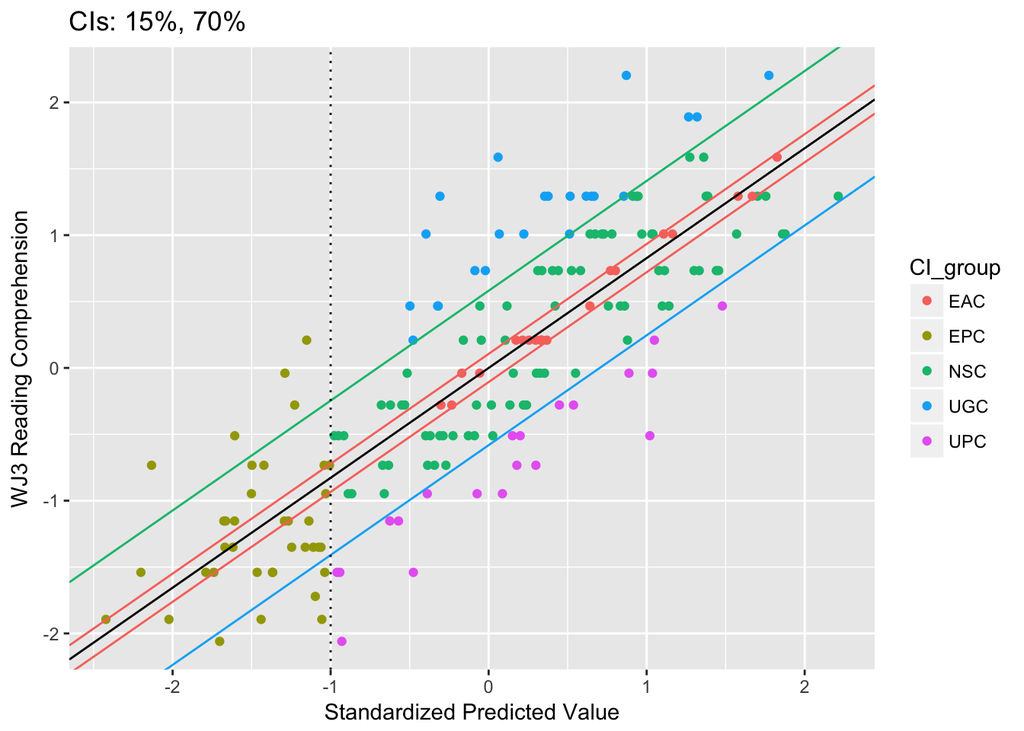

```r
print(p1)
```

```r
LM.WASI.Vocab <- data.frame(table(lmwv.cc$CI_group, lmwv.cc$handedness))
names(LM.WASI.Vocab) <- c("Group", "handedness", "lm.wasi.vocab")
LM.WASI.Vocab.r <- LM.WASI.Vocab[LM.WASI.Vocab$handedness == "right",]
LM.WASI.Vocab.r <- LM.WASI.Vocab.r[,-2]
```

## Linear Model with PPVT

Run model, get groups.

```r
model.data.lmpp <- data[, c(1, 3, 19, 8, 6, 21, 12)]
lmpp.cc <- model.data.lmpp[complete.cases(model.data.lmpp),]
## Checking predictors, outcome
dagoTest(lmpp.cc$decoding.comp)
```

```
##
## Title:
##  D'Agostino Normality Test
##
## Test Results:
##   STATISTIC:
##     Chi2 | Omnibus: 1.0784
##     Z3  | Skewness: -0.9686
##     Z4  | Kurtosis: -0.3745
##   P VALUE:
##     Omnibus  Test: 0.5832
##     Skewness Test: 0.3327
##     Kurtosis Test: 0.7081
##
## Description:
##  Wed May 24 11:22:14 2017 by user:
```

```r
dagoTest(lmpp.cc$wasi.matr.raw)
```

```
##
## Title:
##  D'Agostino Normality Test
##
## Test Results:
##   STATISTIC:
##     Chi2 | Omnibus: 13.0705
##     Z3  | Skewness: -3.6137
##     Z4  | Kurtosis: -0.1086
##   P VALUE:
##     Omnibus  Test: 0.001451
##     Skewness Test: 0.0003019
##     Kurtosis Test: 0.9136
##
## Description:
##  Wed May 24 11:22:14 2017 by user:
```

```r
dagoTest(lmpp.cc$ppvt.raw)
```

```
##
## Title:
##  D'Agostino Normality Test
##
## Test Results:
##   STATISTIC:
##     Chi2 | Omnibus: 19.6522
##     Z3  | Skewness: -4.3978
##     Z4  | Kurtosis: 0.5584
##   P VALUE:
##     Omnibus  Test: 5.402e-05
##     Skewness Test: 1.094e-05
##     Kurtosis Test: 0.5766
##
## Description:
##  Wed May 24 11:22:14 2017 by user:
```

```r
dagoTest(lmpp.cc$wj3.rcomp.raw)
```

```
##
## Title:
##  D'Agostino Normality Test
##
## Test Results:
##   STATISTIC:
##     Chi2 | Omnibus: 13.8473
##     Z3  | Skewness: -1.8679
##     Z4  | Kurtosis: -3.2184
##   P VALUE:
##     Omnibus  Test: 0.0009842
##     Skewness Test: 0.06178
##     Kurtosis Test: 0.001289
##
## Description:
##  Wed May 24 11:22:14 2017 by user:
```

```r
## everything needs to be transformed except the decoding.comp
vars_tf <- c("wasi.matr.raw", "ppvt.raw", "wj3.rcomp.raw")
pp_md_tf <- preProcess(lmpp.cc[,vars_tf], method = c("center", "scale", "YeoJohnson"), na.remove=T)

#check the lambda values associated with the predictors
pp_md_tf$yj$wasi.matr.raw$lambda
```

```
##       Y1
## 2.647398
```

```r
pp_md_tf$yj$ppvt.raw$lambda
```

```
##       Y1
## 5.867009
```

```r
pp_md_tf$yj$wj3.rcomp.raw$lambda
```

```
##       Y1
## 2.462222
```

```r
tf_data <- predict(pp_md_tf, lmpp.cc[,vars_tf])
lmpp.cc$wasi.matr.tf <- tf_data$wasi.matr.raw
lmpp.cc$ppvt.tf <- tf_data$ppvt.raw
lmpp.cc$wj3.rcomp.tf <- tf_data$wj3.rcomp.raw

dagoTest(lmpp.cc$wasi.matr.tf)
```

```
##
## Title:
##  D'Agostino Normality Test
##
## Test Results:
##   STATISTIC:
##     Chi2 | Omnibus: 11.1948
##     Z3  | Skewness: -0.859
##     Z4  | Kurtosis: -3.2337
##   P VALUE:
##     Omnibus  Test: 0.003707
##     Skewness Test: 0.3903
##     Kurtosis Test: 0.001222
##
## Description:
##  Wed May 24 11:22:14 2017 by user:
```

```r
dagoTest(lmpp.cc$ppvt.tf)
```

```
##
## Title:
##  D'Agostino Normality Test
##
## Test Results:
##   STATISTIC:
##     Chi2 | Omnibus: 19.9946
##     Z3  | Skewness: -1.0247
##     Z4  | Kurtosis: -4.3525
##   P VALUE:
##     Omnibus  Test: 4.552e-05
##     Skewness Test: 0.3055
##     Kurtosis Test: 1.346e-05
##
## Description:
##  Wed May 24 11:22:14 2017 by user:
```

```r
dagoTest(lmpp.cc$wj3.rcomp.tf)
```

```
##
## Title:
##  D'Agostino Normality Test
##
## Test Results:
##   STATISTIC:
##     Chi2 | Omnibus: 20.1172
##     Z3  | Skewness: -0.4818
##     Z4  | Kurtosis: -4.4593
##   P VALUE:
##     Omnibus  Test: 4.282e-05
##     Skewness Test: 0.63
##     Kurtosis Test: 8.224e-06
##
## Description:
##  Wed May 24 11:22:14 2017 by user:
```

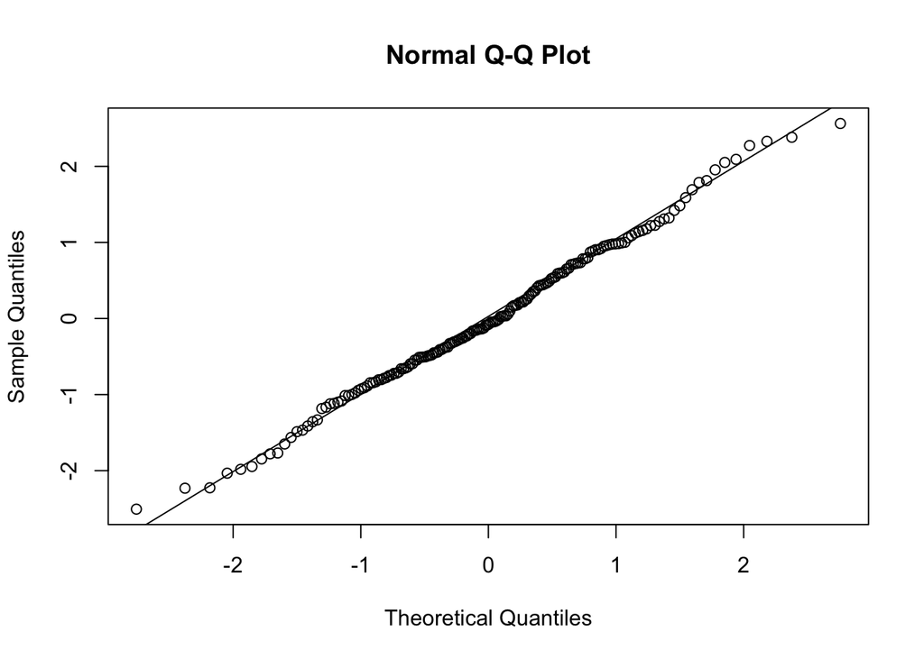

```r
# skewness has pretty much been fixed in all of them -- problem is just kurtosis

# center age
lmpp.cc$age.c <- lmpp.cc$age.beh - mean(lmpp.cc$age.beh, na.rm = TRUE)
# composite has already been scaled

### Run regression
m1 <- lm(wj3.rcomp.tf ~ age.c + decoding.comp + wasi.matr.tf + ppvt.tf, data = lmpp.cc)

#standardize predicted values
lmpp.cc$Pred <- predict(m1)
lmpp.cc$stdPred <- scale(lmpp.cc$Pred)

#obtained residuals
lmpp.cc$resid <- resid <- residuals(m1)
qqnorm(scale(resid)); qqline(scale(resid))
```

```r
#create the range of SD (z value) bins
my.bin <- c(range(scale(resid))+.1, ci2z(ci.to.use), -ci2z(ci.to.use))
#we could also manually specify in terms of SDs
# my.bin <- c(-3, -1, -.25, .25, 1, 3)
my.bin <- sort(my.bin)
# names for each bin specified above
grouping <- c("UPC", "NSC", "EAC", "NSC", "UGC")

lmpp.cc$CI_group <- grouping[findInterval(scale(resid), vec=my.bin, all.inside=T)]
#those with Standardized Predicted Value below -1 should be "EPC"
lmpp.cc$CI_group[lmpp.cc$stdPred < -1] <- "EPC"

### there are five groups c("EAC", "NSC", "UGC", "UPC", "EPC")
### so the argument n = 5
my.col <- gg_color_hue(n=5)

## unscale the z value for each CI, so I can add that value to intercept
unscale.ci <- my.bin[-c(1,length(my.bin))]*sd(resid)+mean(resid)

## create plot
m2 <- lm(wj3.rcomp.tf ~ stdPred, data=lmpp.cc)

p1 <- ggplot(lmpp.cc, aes(x=stdPred, y=wj3.rcomp.tf)) + geom_point(aes(color=CI_group)) +
  geom_abline(intercept = coef(m2)[1], slope = coef(m2)[2]) +
  geom_abline(intercept = coef(m2)[1] + unscale.ci[2], slope = coef(m2)[2], color=my.col[1]) +
  geom_abline(intercept = coef(m2)[1] + unscale.ci[3], slope = coef(m2)[2], color=my.col[1]) +
  geom_abline(intercept = coef(m2)[1] + unscale.ci[1], slope = coef(m2)[2], color=my.col[4]) +
  geom_abline(intercept = coef(m2)[1] + unscale.ci[4], slope = coef(m2)[2], color=my.col[3]) +
  geom_vline(xintercept = -1, lty="dotted") +
  xlab("Standardized Predicted Value")+ylab("WJ3 Reading Comprehension") +
  ggtitle(ci.title)
```

## Group Differences LM2

Linear Model with PPVT

```r
# take away NSC group
lmpp.cc2 <- subset(lmpp.cc, CI_group != "NSC")
lmpp.cc2$CI_group <- as.factor(lmpp.cc2$CI_group)
```

### Reading Comprehension

```r
a1 <- aov(wj3.rcomp.tf ~ CI_group, data = lmpp.cc2)
summary(a1)
```

```
##             Df Sum Sq Mean Sq F value Pr(>F)
## CI_group     3  94.59  31.529   107.9 <2e-16 ***
## Residuals   88  25.72   0.292
## ---
## Signif. codes:  0 '***' 0.001 '**' 0.01 '*' 0.05 '.' 0.1 ' ' 1
```

```r
pairwise.t.test(lmpp.cc2$wj3.rcomp.tf, lmpp.cc2$CI_group, p.adjust.method = "bonferroni")
```

```
##
##  Pairwise comparisons using t tests with pooled SD
##
## data:  lmpp.cc2$wj3.rcomp.tf and lmpp.cc2$CI_group
##
##     EAC     EPC     UGC
## EPC < 2e-16 -       -
## UGC 6.1e-05 < 2e-16 -
## UPC 9.6e-08 0.00039 < 2e-16
##
## P value adjustment method: bonferroni
```

```r
aggregate(lmpp.cc2$wj3.rcomp.tf, list(lmpp.cc2$CI_group), mean)
```

```
##   Group.1          x
## 1     EAC  0.4499454
## 2     EPC -1.3005803
## 3     UGC  1.2611758
## 4     UPC -0.6431972
```

### Age

```r
a1 <- aov(age.c ~ CI_group, data = lmpp.cc2)
summary(a1)
```

```
##             Df Sum Sq Mean Sq F value   Pr(>F)
## CI_group     3  146.1   48.69   7.333 0.000192 ***
## Residuals   88  584.3    6.64
## ---
## Signif. codes:  0 '***' 0.001 '**' 0.01 '*' 0.05 '.' 0.1 ' ' 1
```

```r
pairwise.t.test(lmpp.cc2$age.c, lmpp.cc2$CI_group, p.adjust.method = "bonferroni")
```

```
##
##  Pairwise comparisons using t tests with pooled SD
##
## data:  lmpp.cc2$age.c and lmpp.cc2$CI_group
##
##     EAC     EPC     UGC
## EPC 0.02897 -       -
## UGC 1.00000 0.00076 -
## UPC 1.00000 0.00509 1.00000
##
## P value adjustment method: bonferroni
```

```r
aggregate(lmpp.cc2$age.c, list(lmpp.cc2$CI_group), mean)
```

```
##   Group.1          x
## 1     EAC  0.2843411
## 2     EPC -1.8042542
## 3     UGC  1.1414902
## 4     UPC  0.7783226
```

### Matrix Reasoning

```r
a1 <- aov(wasi.matr.tf ~ CI_group, data = lmpp.cc2)
summary(a1)
```

```
##             Df Sum Sq Mean Sq F value   Pr(>F)
## CI_group     3  39.61  13.204   23.69 2.48e-11 ***
## Residuals   88  49.04   0.557
## ---
## Signif. codes:  0 '***' 0.001 '**' 0.01 '*' 0.05 '.' 0.1 ' ' 1
```

```r
pairwise.t.test(lmpp.cc2$wasi.matr.tf, lmpp.cc2$CI_group, p.adjust.method = "bonferroni")
```

```
##
##  Pairwise comparisons using t tests with pooled SD
##
## data:  lmpp.cc2$wasi.matr.tf and lmpp.cc2$CI_group
##
##     EAC     EPC     UGC
## EPC 2.8e-10 -       -
## UGC 1.00    3.8e-07 -
## UPC 0.26    2.0e-05 1.00
##
## P value adjustment method: bonferroni
```

```r
aggregate(lmpp.cc2$wasi.matr.tf, list(lmpp.cc2$CI_group), mean)
```

```
##   Group.1           x
## 1     EAC  0.46322028
## 2     EPC -1.10800370
## 3     UGC  0.14939641
## 4     UPC -0.03377911
```

### Decoding

```r
a1 <- aov(decoding.comp ~ CI_group, data = lmpp.cc2)
summary(a1)
```

```
##             Df Sum Sq Mean Sq F value   Pr(>F)
## CI_group     3  55.67   18.56   28.12 7.62e-13 ***
## Residuals   88  58.07    0.66
## ---
## Signif. codes:  0 '***' 0.001 '**' 0.01 '*' 0.05 '.' 0.1 ' ' 1
```

```r
pairwise.t.test(lmpp.cc2$decoding.comp, lmpp.cc2$CI_group, p.adjust.method = "bonferroni")
```

```
##
##  Pairwise comparisons using t tests with pooled SD
##
## data:  lmpp.cc2$decoding.comp and lmpp.cc2$CI_group
##
##     EAC     EPC     UGC
## EPC 1.5e-10 -       -
## UGC 1.00    1.4e-09 -
## UPC 0.55    2.4e-06 1.00
##
## P value adjustment method: bonferroni
```

```r
aggregate(lmpp.cc2$decoding.comp, list(lmpp.cc2$CI_group), mean)
```

```
##   Group.1           x
## 1     EAC  0.50760257
## 2     EPC -1.23331855
## 3     UGC  0.42522448
## 4     UPC  0.05688943
```

### PPVT

```r
a1 <- aov(ppvt.tf ~ CI_group, data = lmpp.cc2)
summary(a1)
```

```
##             Df Sum Sq Mean Sq F value Pr(>F)
## CI_group     3  75.77  25.257   57.99 <2e-16 ***
## Residuals   88  38.33   0.436
## ---
## Signif. codes:  0 '***' 0.001 '**' 0.01 '*' 0.05 '.' 0.1 ' ' 1
```

```r
pairwise.t.test(lmpp.cc2$ppvt.tf, lmpp.cc2$CI_group, p.adjust.method = "bonferroni")
```

```
##
##  Pairwise comparisons using t tests with pooled SD
##
## data:  lmpp.cc2$ppvt.tf and lmpp.cc2$CI_group
##
##     EAC     EPC     UGC
## EPC 2.6e-16 -       -
## UGC 1       1.3e-15 -
## UPC 1       1.1e-13 1
##
## P value adjustment method: bonferroni
```

```r
aggregate(lmpp.cc2$ppvt.tf, list(lmpp.cc2$CI_group), mean)
```

```
##   Group.1          x
## 1     EAC  0.5051889
## 2     EPC -1.4272623
## 3     UGC  0.4720132
## 4     UPC  0.3270546
```

Show group sizes, plot.

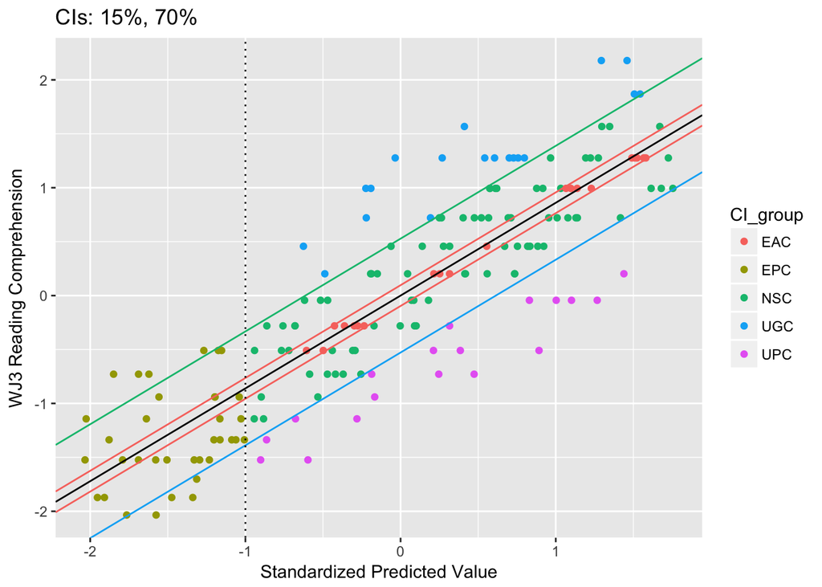

```r
print(p1)
```

```r
LM.PPVT <- data.frame(table(lmpp.cc$CI_group, lmpp.cc$handedness))
names(LM.PPVT) <- c("Group", "handedness", "lm.ppvt")
LM.PPVT.r <- LM.PPVT[LM.PPVT$handedness == "right",]
LM.PPVT.r <- LM.PPVT.r[,-2]
```

## Linear Model with Vocabulary Composite

Run model, get groups.

```r
model.data.lmvc <- data[, c(1, 3, 19, 8, 22, 21, 12)]
lmvc.cc <- model.data.lmvc[complete.cases(model.data.lmvc),]
## Checking predictors, outcome
dagoTest(lmvc.cc$decoding.comp)
```

```
##
## Title:
##  D'Agostino Normality Test
##
## Test Results:
##   STATISTIC:
##     Chi2 | Omnibus: 1.0784
##     Z3  | Skewness: -0.9686
##     Z4  | Kurtosis: -0.3745
##   P VALUE:
##     Omnibus  Test: 0.5832
##     Skewness Test: 0.3327
##     Kurtosis Test: 0.7081
##
## Description:
##  Wed May 24 11:22:16 2017 by user:
```

```r
dagoTest(lmvc.cc$wasi.matr.raw)
```

```
##
## Title:
##  D'Agostino Normality Test
##
## Test Results:
##   STATISTIC:
##     Chi2 | Omnibus: 13.0705
##     Z3  | Skewness: -3.6137
##     Z4  | Kurtosis: -0.1086
##   P VALUE:
##     Omnibus  Test: 0.001451
##     Skewness Test: 0.0003019
##     Kurtosis Test: 0.9136
##
## Description:
##  Wed May 24 11:22:16 2017 by user:
```

```r
dagoTest(lmvc.cc$vocab.comp)
```

```
##
## Title:
##  D'Agostino Normality Test
##
## Test Results:
##   STATISTIC:
##     Chi2 | Omnibus: 13.6193
##     Z3  | Skewness: -0.8471
##     Z4  | Kurtosis: -3.5919
##   P VALUE:
##     Omnibus  Test: 0.001103
##     Skewness Test: 0.397
##     Kurtosis Test: 0.0003283
##
## Description:
##  Wed May 24 11:22:16 2017 by user:
```

```r
dagoTest(lmvc.cc$wj3.rcomp.raw)
```

```
##
## Title:
##  D'Agostino Normality Test
##
## Test Results:
##   STATISTIC:
##     Chi2 | Omnibus: 13.8473
##     Z3  | Skewness: -1.8679
##     Z4  | Kurtosis: -3.2184
##   P VALUE:
##     Omnibus  Test: 0.0009842
##     Skewness Test: 0.06178
##     Kurtosis Test: 0.001289
##
## Description:
##  Wed May 24 11:22:16 2017 by user:
```

```r
## everything needs to be transformed except the decoding.comp, vocab comp
vars_tf <- c("wasi.matr.raw", "wj3.rcomp.raw")
pp_md_tf <- preProcess(lmvc.cc[,vars_tf], method = c("center", "scale", "YeoJohnson"), na.remove=T)

#check the lambda values associated with the predictors
pp_md_tf$yj$wasi.matr.raw$lambda
```

```
##       Y1
## 2.647398
```

```r
pp_md_tf$yj$vocab.comp$lambda
```

```r
pp_md_tf$yj$wj3.rcomp.raw$lambda
```

```
##       Y1
## 2.462222
```

```r
tf_data <- predict(pp_md_tf, lmvc.cc[,vars_tf])
lmvc.cc$wasi.matr.tf <- tf_data$wasi.matr.raw
lmvc.cc$wj3.rcomp.tf <- tf_data$wj3.rcomp.raw

dagoTest(lmvc.cc$wasi.matr.tf)
```

```
##
## Title:
##  D'Agostino Normality Test
##
## Test Results:
##   STATISTIC:
##     Chi2 | Omnibus: 11.1948
##     Z3  | Skewness: -0.859
##     Z4  | Kurtosis: -3.2337
##   P VALUE:
##     Omnibus  Test: 0.003707
##     Skewness Test: 0.3903
##     Kurtosis Test: 0.001222
##
## Description:
##  Wed May 24 11:22:16 2017 by user:
```

```r
dagoTest(lmvc.cc$wj3.rcomp.tf)
```

```
##
## Title:
##  D'Agostino Normality Test
##
## Test Results:
##   STATISTIC:
##     Chi2 | Omnibus: 20.1172
##     Z3  | Skewness: -0.4818
##     Z4  | Kurtosis: -4.4593
##   P VALUE:
##     Omnibus  Test: 4.282e-05
##     Skewness Test: 0.63
##     Kurtosis Test: 8.224e-06
##
## Description:
##  Wed May 24 11:22:16 2017 by user:
```

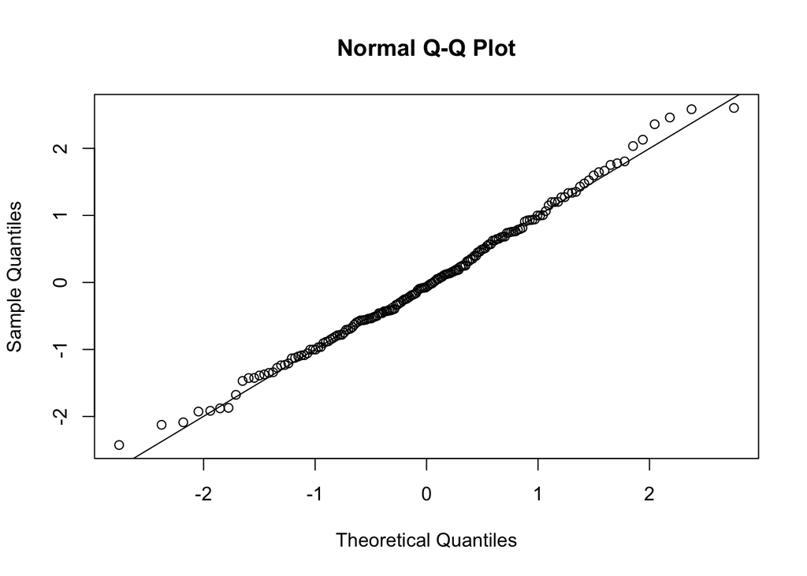

```r
# skewness has pretty much been fixed in all of them -- problem is just kurtosis

# center age
lmvc.cc$age.c <- lmvc.cc$age.beh - mean(lmvc.cc$age.beh, na.rm = TRUE)
# composites have already been scaled

### Run regression
m1 <- lm(wj3.rcomp.tf ~ age.c + decoding.comp + wasi.matr.tf + vocab.comp, data = lmvc.cc)

#standardize predicted values
lmvc.cc$Pred <- predict(m1)
lmvc.cc$stdPred <- scale(lmvc.cc$Pred)

#obtained residuals
lmvc.cc$resid <- resid <- residuals(m1)
qqnorm(scale(resid)); qqline(scale(resid))
```

```r
#create the range of SD (z value) bins
my.bin <- c(range(scale(resid))+.1, ci2z(ci.to.use), -ci2z(ci.to.use))
#we could also manually specify in terms of SDs
# my.bin <- c(-3, -1, -.25, .25, 1, 3)
my.bin <- sort(my.bin)
# names for each bin specified above
grouping <- c("UPC", "NSC", "EAC", "NSC", "UGC")

lmvc.cc$CI_group <- grouping[findInterval(scale(resid), vec=my.bin, all.inside=T)]
#those with Standardized Predicted Value below -1 should be "EPC"
lmvc.cc$CI_group[lmvc.cc$stdPred < -1] <- "EPC"

### there are five groups c("EAC", "NSC", "UGC", "UPC", "EPC")
### so the argument n = 5
my.col <- gg_color_hue(n=5)

## unscale the z value for each CI, so I can add that value to intercept
unscale.ci <- my.bin[-c(1,length(my.bin))]*sd(resid)+mean(resid)

## create plot
m2 <- lm(wj3.rcomp.tf ~ stdPred, data=lmvc.cc)

p1 <- ggplot(lmvc.cc, aes(x=stdPred, y=wj3.rcomp.tf)) + geom_point(aes(color=CI_group)) +
  geom_abline(intercept = coef(m2)[1], slope = coef(m2)[2]) +
  geom_abline(intercept = coef(m2)[1] + unscale.ci[2], slope = coef(m2)[2], color=my.col[1]) +
  geom_abline(intercept = coef(m2)[1] + unscale.ci[3], slope = coef(m2)[2], color=my.col[1]) +
  geom_abline(intercept = coef(m2)[1] + unscale.ci[1], slope = coef(m2)[2], color=my.col[4]) +
  geom_abline(intercept = coef(m2)[1] + unscale.ci[4], slope = coef(m2)[2], color=my.col[3]) +
  geom_vline(xintercept = -1, lty="dotted") +
  xlab("Standardized Predicted Value")+ylab("WJ3 Reading Comprehension") +
  ggtitle(ci.title)
```

## Group Differences LM3

Linear Model with Vocab Composite

```r
# take away NSC group
lmvc.cc2 <- subset(lmvc.cc, CI_group != "NSC")
lmvc.cc2$CI_group <- as.factor(lmvc.cc2$CI_group)
```

### Reading Comprehension

```r
a1 <- aov(wj3.rcomp.tf ~ CI_group, data = lmvc.cc2)
summary(a1)
```

```
##             Df Sum Sq Mean Sq F value Pr(>F)
## CI_group     3  93.25  31.082   95.68 <2e-16 ***
## Residuals   90  29.24   0.325
## ---
## Signif. codes:  0 '***' 0.001 '**' 0.01 '*' 0.05 '.' 0.1 ' ' 1
```

```r
pairwise.t.test(lmvc.cc2$wj3.rcomp.tf, lmvc.cc2$CI_group, p.adjust.method = "bonferroni")
```

```
##
##  Pairwise comparisons using t tests with pooled SD
##
## data:  lmvc.cc2$wj3.rcomp.tf and lmvc.cc2$CI_group
##
##     EAC     EPC     UGC
## EPC < 2e-16 -       -
## UGC 0.0076  < 2e-16 -
## UPC 5.3e-05 9.8e-07 6.2e-12
##
## P value adjustment method: bonferroni
```

```r
aggregate(lmvc.cc2$wj3.rcomp.tf, list(lmvc.cc2$CI_group), mean)
```

```
##   Group.1          x
## 1     EAC  0.6088868
## 2     EPC -1.2226411
## 3     UGC  1.2346222
## 4     UPC -0.3000826
```

### Age

```r
a1 <- aov(age.c ~ CI_group, data = lmvc.cc2)
summary(a1)
```

```
##             Df Sum Sq Mean Sq F value   Pr(>F)
## CI_group     3  150.4   50.14   7.365 0.000181 ***
## Residuals   90  612.7    6.81
## ---
## Signif. codes:  0 '***' 0.001 '**' 0.01 '*' 0.05 '.' 0.1 ' ' 1
```

```r
pairwise.t.test(lmvc.cc2$age.c, lmvc.cc2$CI_group, p.adjust.method = "bonferroni")
```

```
##
##  Pairwise comparisons using t tests with pooled SD
##
## data:  lmvc.cc2$age.c and lmvc.cc2$CI_group
##
##     EAC     EPC     UGC
## EPC 0.01377 -       -
## UGC 1.00000 0.00096 -
## UPC 1.00000 0.01092 1.00000
##
## P value adjustment method: bonferroni
```

```r
aggregate(lmvc.cc2$age.c, list(lmvc.cc2$CI_group), mean)
```

```
##   Group.1          x
## 1     EAC  0.6698803
## 2     EPC -1.7102102
## 3     UGC  1.1178411
## 4     UPC  0.6790633
```

### Matrix Reasoning

```r
a1 <- aov(wasi.matr.tf ~ CI_group, data = lmvc.cc2)
summary(a1)
```

```
##             Df Sum Sq Mean Sq F value   Pr(>F)
## CI_group     3  45.97   15.32   27.38 1.13e-12 ***
## Residuals   90  50.37    0.56
## ---
## Signif. codes:  0 '***' 0.001 '**' 0.01 '*' 0.05 '.' 0.1 ' ' 1
```

```r
pairwise.t.test(lmvc.cc2$wasi.matr.tf, lmvc.cc2$CI_group, p.adjust.method = "bonferroni")
```

```
##
##  Pairwise comparisons using t tests with pooled SD
##
## data:  lmvc.cc2$wasi.matr.tf and lmvc.cc2$CI_group
##
##     EAC     EPC     UGC
## EPC 9.6e-10 -       -
## UGC 1       9.2e-09 -
## UPC 1       2.4e-07 1
##
## P value adjustment method: bonferroni
```

```r
aggregate(lmvc.cc2$wasi.matr.tf, list(lmvc.cc2$CI_group), mean)
```

```
##   Group.1          x
## 1     EAC  0.4932571
## 2     EPC -1.0763867
## 3     UGC  0.3082376
## 4     UPC  0.2039379
```

### Decoding

```r
a1 <- aov(decoding.comp ~ CI_group, data = lmvc.cc2)
summary(a1)
```

```
##             Df Sum Sq Mean Sq F value   Pr(>F)
## CI_group     3  65.83  21.942   35.78 2.57e-15 ***
## Residuals   90  55.19   0.613
## ---
## Signif. codes:  0 '***' 0.001 '**' 0.01 '*' 0.05 '.' 0.1 ' ' 1
```

```r
pairwise.t.test(lmvc.cc2$decoding.comp, lmvc.cc2$CI_group, p.adjust.method = "bonferroni")
```

```
##
##  Pairwise comparisons using t tests with pooled SD
##
## data:  lmvc.cc2$decoding.comp and lmvc.cc2$CI_group
##
##     EAC     EPC     UGC
## EPC 1.0e-11 -       -
## UGC 0.72    8.0e-09 -
## UPC 1.00    5.3e-11 1.00
##
## P value adjustment method: bonferroni
```

```r
aggregate(lmvc.cc2$decoding.comp, list(lmvc.cc2$CI_group), mean)
```

```
##   Group.1          x
## 1     EAC  0.6877973
## 2     EPC -1.1733446
## 3     UGC  0.2825205
## 4     UPC  0.5755814
```

### Vocab Composite

```r
a1 <- aov(vocab.comp ~ CI_group, data = lmvc.cc2)
summary(a1)
```

```
##             Df Sum Sq Mean Sq F value Pr(>F)
## CI_group     3  89.43  29.811   83.91 <2e-16 ***
## Residuals   90  31.98   0.355
## ---
## Signif. codes:  0 '***' 0.001 '**' 0.01 '*' 0.05 '.' 0.1 ' ' 1
```

```r
pairwise.t.test(lmvc.cc2$vocab.comp, lmvc.cc2$CI_group, p.adjust.method = "bonferroni")
```

```
##
##  Pairwise comparisons using t tests with pooled SD
##
## data:  lmvc.cc2$vocab.comp and lmvc.cc2$CI_group
##
##     EAC    EPC    UGC
## EPC <2e-16 -      -
## UGC 1      <2e-16 -
## UPC 1      <2e-16 1
##
## P value adjustment method: bonferroni
```

```r
aggregate(lmvc.cc2$vocab.comp, list(lmvc.cc2$CI_group), mean)
```

```
##   Group.1          x
## 1     EAC  0.6820277
## 2     EPC -1.4231798
## 3     UGC  0.4224958
## 4     UPC  0.5656442
```

Show group sizes, plot.

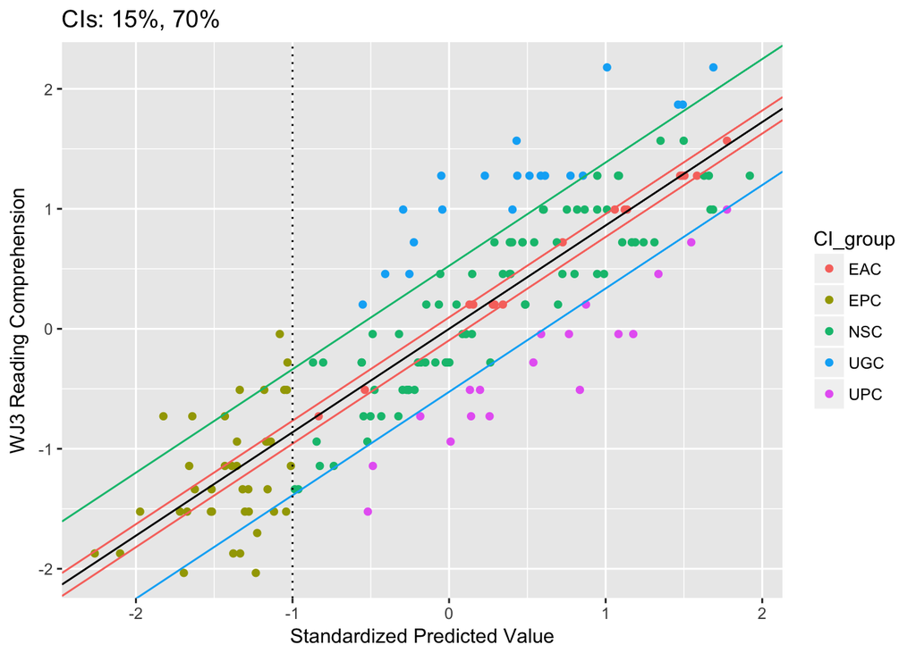

```r
print(p1)
```

```r
LM.VC <- data.frame(table(lmvc.cc$CI_group, lmvc.cc$handedness))
names(LM.VC) <- c("Group", "handedness", "lm.vocab.composite")
LM.VC.r <- LM.VC[LM.VC$handedness == "right",]
LM.VC.r <- LM.VC.r[,-2]
```

## Linear Model with Oral Comprehension

Run model, get groups.

```r
model.data.lmoc <- data[, c(1, 3, 19, 8, 13, 21, 12)]
lmoc.cc <- model.data.lmoc[complete.cases(model.data.lmoc),]
## Checking predictors, outcome
dagoTest(lmoc.cc$decoding.comp)
```

```
##
## Title:
##  D'Agostino Normality Test
##
## Test Results:
##   STATISTIC:
##     Chi2 | Omnibus: 1.3609
##     Z3  | Skewness: -1.1648
##     Z4  | Kurtosis: -0.0648
##   P VALUE:
##     Omnibus  Test: 0.5064
##     Skewness Test: 0.2441
##     Kurtosis Test: 0.9483
##
## Description:
##  Wed May 24 11:22:18 2017 by user:
```

```r
dagoTest(lmoc.cc$wasi.matr.raw)
```

```
##
## Title:
##  D'Agostino Normality Test
##
## Test Results:
##   STATISTIC:
##     Chi2 | Omnibus: 13.6465
##     Z3  | Skewness: -3.6906
##     Z4  | Kurtosis: -0.162
##   P VALUE:
##     Omnibus  Test: 0.001088
##     Skewness Test: 0.0002238
##     Kurtosis Test: 0.8713
##
## Description:
##  Wed May 24 11:22:18 2017 by user:
```

```r
dagoTest(lmoc.cc$wj3.oralcomp.raw)
```

```
##
## Title:
##  D'Agostino Normality Test
##
## Test Results:
##   STATISTIC:
##     Chi2 | Omnibus: 22.3113
##     Z3  | Skewness: -4.4192
##     Z4  | Kurtosis: 1.6679
##   P VALUE:
##     Omnibus  Test: 1.429e-05
##     Skewness Test: 9.906e-06
##     Kurtosis Test: 0.09534
##
## Description:
##  Wed May 24 11:22:18 2017 by user:
```

```r
dagoTest(lmoc.cc$wj3.rcomp.raw)
```

```
##
## Title:
##  D'Agostino Normality Test
##
## Test Results:
##   STATISTIC:
##     Chi2 | Omnibus: 13.1668
##     Z3  | Skewness: -1.8058
##     Z4  | Kurtosis: -3.1474
##   P VALUE:
##     Omnibus  Test: 0.001383
##     Skewness Test: 0.07095
##     Kurtosis Test: 0.001648
##
## Description:
##  Wed May 24 11:22:18 2017 by user:
```

```r
## everything needs to be transformed except the decoding.comp
vars_tf <- c("wasi.matr.raw", "wj3.oralcomp.raw", "wj3.rcomp.raw")
pp_md_tf <- preProcess(lmoc.cc[,vars_tf], method = c("center", "scale", "YeoJohnson"), na.remove=T)

#check the lambda values associated with the predictors
pp_md_tf$yj$wasi.matr.raw$lambda
```

```
##       Y1
## 2.681323
```

```r
pp_md_tf$yj$wj3.oralcomp$lambda
```

```
##       Y1
## 3.415803
```

```r
pp_md_tf$yj$wj3.rcomp.raw$lambda
```

```
##       Y1
## 2.399951
```

```r
tf_data <- predict(pp_md_tf, lmoc.cc[,vars_tf])
lmoc.cc$wasi.matr.tf <- tf_data$wasi.matr.raw
lmoc.cc$wj3.oralcomp.tf <- tf_data$wj3.oralcomp.raw
lmoc.cc$wj3.rcomp.tf <- tf_data$wj3.rcomp.raw

dagoTest(lmoc.cc$wasi.matr.tf)
```

```
##
## Title:
##  D'Agostino Normality Test
##
## Test Results:
##   STATISTIC:
##     Chi2 | Omnibus: 11.2381
##     Z3  | Skewness: -0.8874
##     Z4  | Kurtosis: -3.2327
##   P VALUE:
##     Omnibus  Test: 0.003628
##     Skewness Test: 0.3748
##     Kurtosis Test: 0.001226
##
## Description:
##  Wed May 24 11:22:18 2017 by user:
```

```r
dagoTest(lmoc.cc$wj3.oralcomp.tf)
```

```
##
## Title:
##  D'Agostino Normality Test
##
## Test Results:
##   STATISTIC:
##     Chi2 | Omnibus: 12.5923
##     Z3  | Skewness: -0.8644
##     Z4  | Kurtosis: -3.4417
##   P VALUE:
##     Omnibus  Test: 0.001843
##     Skewness Test: 0.3874
##     Kurtosis Test: 0.0005781
##
## Description:
##  Wed May 24 11:22:18 2017 by user:
```

```r
dagoTest(lmoc.cc$wj3.rcomp.tf)
```

```
##
## Title:
##  D'Agostino Normality Test
##
## Test Results:
##   STATISTIC:
##     Chi2 | Omnibus: 19.1844
##     Z3  | Skewness: -0.4533
##     Z4  | Kurtosis: -4.3565
##   P VALUE:
##     Omnibus  Test: 6.826e-05
##     Skewness Test: 0.6503
##     Kurtosis Test: 1.322e-05
##
## Description:
##  Wed May 24 11:22:18 2017 by user:
```

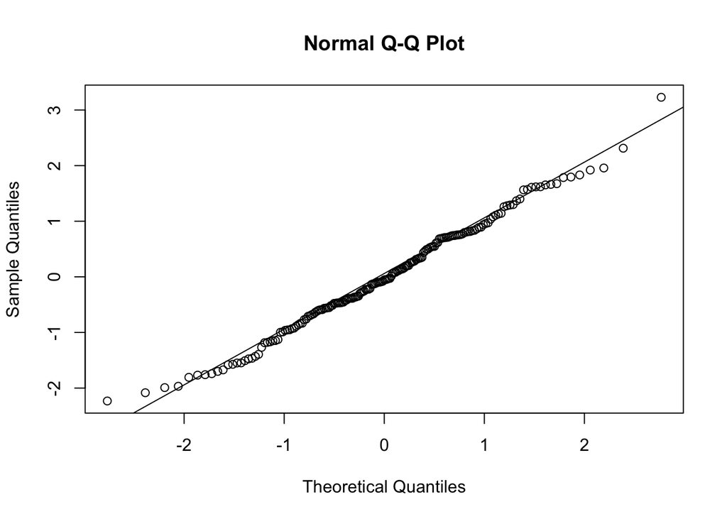

```r
# skewness has pretty much been fixed in all of them -- problem is just kurtosis

# center age
lmoc.cc$age.c <- lmoc.cc$age.beh - mean(lmoc.cc$age.beh, na.rm = TRUE)
# composite has already been scaled

### Run regression
m1 <- lm(wj3.rcomp.tf ~ age.c + decoding.comp + wasi.matr.tf + wj3.oralcomp.tf, data = lmoc.cc)

#standardize predicted values
lmoc.cc$Pred <- predict(m1)
lmoc.cc$stdPred <- scale(lmoc.cc$Pred)

#obtained residuals
lmoc.cc$resid <- resid <- residuals(m1)
qqnorm(scale(resid)); qqline(scale(resid))
```

```r
#create the range of SD (z value) bins
my.bin <- c(range(scale(resid))+.1, ci2z(ci.to.use), -ci2z(ci.to.use))
#we could also manually specify in terms of SDs
# my.bin <- c(-3, -1, -.25, .25, 1, 3)
my.bin <- sort(my.bin)
# names for each bin specified above
grouping <- c("UPC", "NSC", "EAC", "NSC", "UGC")

lmoc.cc$CI_group <- grouping[findInterval(scale(resid), vec=my.bin, all.inside=T)]
#those with Standardized Predicted Value below -1 should be "EPC"
lmoc.cc$CI_group[lmoc.cc$stdPred < -1] <- "EPC"

### there are five groups c("EAC", "NSC", "UGC", "UPC", "EPC")
### so the argument n = 5
my.col <- gg_color_hue(n=5)

## unscale the z value for each CI, so I can add that value to intercept
unscale.ci <- my.bin[-c(1,length(my.bin))]*sd(resid)+mean(resid)

## create plot
m2 <- lm(wj3.rcomp.tf ~ stdPred, data=lmoc.cc)

p1 <- ggplot(lmoc.cc, aes(x=stdPred, y=wj3.rcomp.tf)) + geom_point(aes(color=CI_group)) +
  geom_abline(intercept = coef(m2)[1], slope = coef(m2)[2]) +
  geom_abline(intercept = coef(m2)[1] + unscale.ci[2], slope = coef(m2)[2], color=my.col[1]) +
  geom_abline(intercept = coef(m2)[1] + unscale.ci[3], slope = coef(m2)[2], color=my.col[1]) +
  geom_abline(intercept = coef(m2)[1] + unscale.ci[1], slope = coef(m2)[2], color=my.col[4]) +
  geom_abline(intercept = coef(m2)[1] + unscale.ci[4], slope = coef(m2)[2], color=my.col[3]) +
  geom_vline(xintercept = -1, lty="dotted") +
  xlab("Standardized Predicted Value")+ylab("WJ3 Reading Comprehension") +
  ggtitle(ci.title)
```

## Group Differences LM4

Linear Model with Oral Comprehension

```r
# take away NSC group
lmoc.cc2 <- subset(lmoc.cc, CI_group != "NSC")
lmoc.cc2$CI_group <- as.factor(lmoc.cc2$CI_group)
```

### Reading Comprehension

```r
a1 <- aov(wj3.rcomp.tf ~ CI_group, data = lmoc.cc2)
summary(a1)
```

```
##             Df Sum Sq Mean Sq F value Pr(>F)
## CI_group     3  81.91  27.303   80.51 <2e-16 ***
## Residuals   88  29.84   0.339
## ---
## Signif. codes:  0 '***' 0.001 '**' 0.01 '*' 0.05 '.' 0.1 ' ' 1
```

```r
pairwise.t.test(lmoc.cc2$wj3.rcomp.tf, lmoc.cc2$CI_group, p.adjust.method = "bonferroni")
```

```
##
##  Pairwise comparisons using t tests with pooled SD
##
## data:  lmoc.cc2$wj3.rcomp.tf and lmoc.cc2$CI_group
##
##     EAC     EPC     UGC
## EPC 8.5e-14 -       -
## UGC 0.00021 < 2e-16 -
## UPC 5.4e-06 0.00313 2.6e-15
##
## P value adjustment method: bonferroni
```

```r
aggregate(lmoc.cc2$wj3.rcomp.tf, list(lmoc.cc2$CI_group), mean)
```

```
##   Group.1          x
## 1     EAC  0.3655213
## 2     EPC -1.2151215
## 3     UGC  1.2245316
## 4     UPC -0.6391173
```

### Age

```r
a1 <- aov(age.c ~ CI_group, data = lmoc.cc2)
summary(a1)
```

```
##             Df Sum Sq Mean Sq F value  Pr(>F)
## CI_group     3   93.3  31.090   4.839 0.00365 **
## Residuals   88  565.4   6.425
## ---
## Signif. codes:  0 '***' 0.001 '**' 0.01 '*' 0.05 '.' 0.1 ' ' 1
```

```r
pairwise.t.test(lmoc.cc2$age.c, lmoc.cc2$CI_group, p.adjust.method = "bonferroni")
```

```
##
##  Pairwise comparisons using t tests with pooled SD
##
## data:  lmoc.cc2$age.c and lmoc.cc2$CI_group
##
##     EAC   EPC   UGC
## EPC 0.013 -     -
## UGC 1.000 0.056 -
## UPC 1.000 0.056 1.000
##
## P value adjustment method: bonferroni
```

```r
aggregate(lmoc.cc2$age.c, list(lmoc.cc2$CI_group), mean)
```

```
##   Group.1          x
## 1     EAC  0.7165936
## 2     EPC -1.6389783
## 3     UGC  0.3055587
## 4     UPC  0.2114582
```

### Matrix Reasoning

```r
a1 <- aov(wasi.matr.tf ~ CI_group, data = lmoc.cc2)
summary(a1)
```

```
##             Df Sum Sq Mean Sq F value  Pr(>F)
## CI_group     3  40.72  13.573   22.95 4.6e-11 ***
## Residuals   88  52.05   0.591
## ---
## Signif. codes:  0 '***' 0.001 '**' 0.01 '*' 0.05 '.' 0.1 ' ' 1
```

```r
pairwise.t.test(lmoc.cc2$wasi.matr.tf, lmoc.cc2$CI_group, p.adjust.method = "bonferroni")
```

```
##
##  Pairwise comparisons using t tests with pooled SD
##
## data:  lmoc.cc2$wasi.matr.tf and lmoc.cc2$CI_group
##
##     EAC     EPC     UGC
## EPC 7.4e-08 -       -
## UGC 1       2.4e-07 -
## UPC 1       6.3e-08 1
##
## P value adjustment method: bonferroni
```

```r
aggregate(lmoc.cc2$wasi.matr.tf, list(lmoc.cc2$CI_group), mean)
```

```
##   Group.1          x
## 1     EAC  0.2383888
## 2     EPC -1.1839094
## 3     UGC  0.1519080
## 4     UPC  0.1507523
```

### Decoding

```r
a1 <- aov(decoding.comp ~ CI_group, data = lmoc.cc2)
summary(a1)
```

```
##             Df Sum Sq Mean Sq F value   Pr(>F)
## CI_group     3  56.32  18.775   35.87 3.07e-15 ***
## Residuals   88  46.06   0.523
## ---
## Signif. codes:  0 '***' 0.001 '**' 0.01 '*' 0.05 '.' 0.1 ' ' 1
```

```r
pairwise.t.test(lmoc.cc2$decoding.comp, lmoc.cc2$CI_group, p.adjust.method = "bonferroni")
```

```
##
##  Pairwise comparisons using t tests with pooled SD
##
## data:  lmoc.cc2$decoding.comp and lmoc.cc2$CI_group
##
##     EAC     EPC     UGC
## EPC 2.1e-11 -       -
## UGC 1       4.4e-11 -
## UPC 1       8.7e-10 1
##
## P value adjustment method: bonferroni
```

```r
aggregate(lmoc.cc2$decoding.comp, list(lmoc.cc2$CI_group), mean)
```

```
##   Group.1          x
## 1     EAC  0.4449667
## 2     EPC -1.2702471
## 3     UGC  0.3798092
## 4     UPC  0.1721761
```

### Oral Comprehension

```r
a1 <- aov(wj3.oralcomp.tf ~ CI_group, data = lmoc.cc2)
summary(a1)
```

```
##             Df Sum Sq Mean Sq F value Pr(>F)
## CI_group     3  61.10  20.367   46.61 <2e-16 ***
## Residuals   88  38.45   0.437
## ---
## Signif. codes:  0 '***' 0.001 '**' 0.01 '*' 0.05 '.' 0.1 ' ' 1
```

```r
pairwise.t.test(lmoc.cc2$wj3.oralcomp.tf, lmoc.cc2$CI_group, p.adjust.method = "bonferroni")
```

```
##
##  Pairwise comparisons using t tests with pooled SD
##
## data:  lmoc.cc2$wj3.oralcomp.tf and lmoc.cc2$CI_group
##
##     EAC     EPC     UGC
## EPC 1.6e-12 -       -
## UGC 1       1.7e-13 -
## UPC 1       4.8e-13 1
##
## P value adjustment method: bonferroni
```

```r
aggregate(lmoc.cc2$wj3.oralcomp.tf, list(lmoc.cc2$CI_group), mean)
```

```
##   Group.1          x
## 1     EAC  0.3311352
## 2     EPC -1.3421876
## 3     UGC  0.3898016
## 4     UPC  0.2661226
```

Show group sizes, plot.

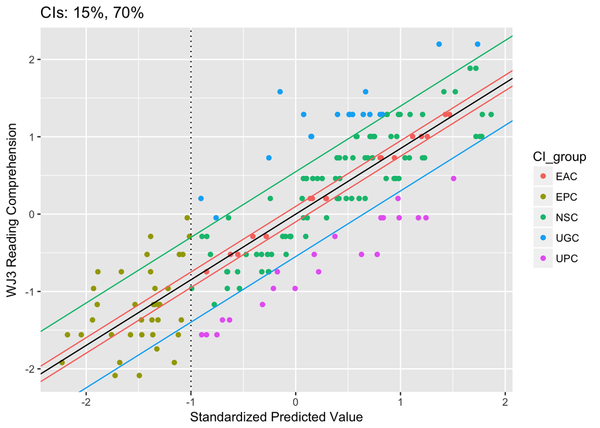

```r
print(p1)
```

```r
LM.OC <- data.frame(table(lmoc.cc$CI_group, lmoc.cc$handedness))
names(LM.OC) <- c("Group", "handedness", "lm.oralcomp")
LM.OC.r <- LM.OC[LM.OC$handedness == "right",]
LM.OC.r <- LM.OC.r[,-2]
```

## Robust Model with WASI Vocab

Run model, get groups.

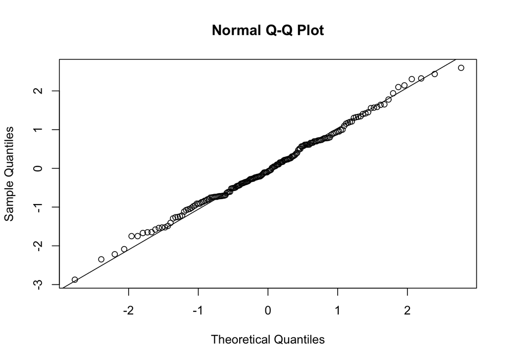

```r
model.data.rlmwv <- data[, c(1, 3, 19, 8, 7, 21, 12)]
rlmwv.cc <- model.data.rlmwv[complete.cases(model.data.rlmwv),]

# center and scale predictors
rlmwv.cc$wasi.matr.cs <- scale(rlmwv.cc$wasi.matr.raw)
rlmwv.cc$wasi.vocab.cs <- scale(rlmwv.cc$wasi.vocab.raw)
rlmwv.cc$wj3.rcomp.cs <- scale(rlmwv.cc$wj3.rcomp.raw)

# center age
rlmwv.cc$age.c <- rlmwv.cc$age.beh - mean(rlmwv.cc$age.beh, na.rm = TRUE)
# composite has already been scaled

### Run regression
m1 <- rlm(wj3.rcomp.cs ~ age.c + decoding.comp + wasi.matr.cs + wasi.vocab.cs, data = rlmwv.cc, method = "MM")

#standardize predicted values
rlmwv.cc$Pred <- predict(m1)
rlmwv.cc$stdPred <- scale(rlmwv.cc$Pred)

#obtained residuals
rlmwv.cc$resid <- resid <- residuals(m1)
qqnorm(scale(resid)); qqline(scale(resid))
```

```r
#create the range of SD (z value) bins
my.bin <- c(range(scale(resid))+.1, ci2z(ci.to.use), -ci2z(ci.to.use))
#we could also manually specify in terms of SDs
# my.bin <- c(-3, -1, -.25, .25, 1, 3)
my.bin <- sort(my.bin)
# names for each bin specified above
grouping <- c("UPC", "NSC", "EAC", "NSC", "UGC")

rlmwv.cc$CI_group <- grouping[findInterval(scale(resid), vec=my.bin, all.inside=T)]
#those with Standardized Predicted Value below -1 should be "EPC"
rlmwv.cc$CI_group[rlmwv.cc$stdPred < -1] <- "EPC"

### there are five groups c("EAC", "NSC", "UGC", "UPC", "EPC")
### so the argument n = 5
my.col <- gg_color_hue(n=5)

## unscale the z value for each CI, so I can add that value to intercept
unscale.ci <- my.bin[-c(1,length(my.bin))]*sd(resid)+mean(resid)

## create plot
m2 <- lm(wj3.rcomp.cs ~ stdPred, data=rlmwv.cc)

p1 <- ggplot(rlmwv.cc, aes(x=stdPred, y=wj3.rcomp.cs)) + geom_point(aes(color=CI_group)) +
  geom_abline(intercept = coef(m2)[1], slope = coef(m2)[2]) +
  geom_abline(intercept = coef(m2)[1] + unscale.ci[2], slope = coef(m2)[2], color=my.col[1]) +
  geom_abline(intercept = coef(m2)[1] + unscale.ci[3], slope = coef(m2)[2], color=my.col[1]) +
  geom_abline(intercept = coef(m2)[1] + unscale.ci[1], slope = coef(m2)[2], color=my.col[4]) +
  geom_abline(intercept = coef(m2)[1] + unscale.ci[4], slope = coef(m2)[2], color=my.col[3]) +
  geom_vline(xintercept = -1, lty="dotted") +
  xlab("Standardized Predicted Value")+ylab("WJ3 Reading Comprehension") +
  ggtitle(ci.title)
```

## Group Differences RLM1

Robust Model with WASI Vocab

```r
# take away NSC group
rlmwv.cc2 <- subset(rlmwv.cc, CI_group != "NSC")
rlmwv.cc2$CI_group <- as.factor(rlmwv.cc2$CI_group)
```

### Reading Comprehension

```r
a1 <- aov(wj3.rcomp.cs ~ CI_group, data = rlmwv.cc2)
summary(a1)
```

```
##             Df Sum Sq Mean Sq F value Pr(>F)
## CI_group     3  88.04  29.348   80.62 <2e-16 ***
## Residuals   92  33.49   0.364
## ---
## Signif. codes:  0 '***' 0.001 '**' 0.01 '*' 0.05 '.' 0.1 ' ' 1
```

```r
pairwise.t.test(rlmwv.cc2$wj3.rcomp.cs, rlmwv.cc2$CI_group, p.adjust.method = "bonferroni")
```

```
##
##  Pairwise comparisons using t tests with pooled SD
##
## data:  rlmwv.cc2$wj3.rcomp.cs and rlmwv.cc2$CI_group
##
##     EAC     EPC     UGC
## EPC < 2e-16 -       -
## UGC 0.018   < 2e-16 -
## UPC 2.6e-08 0.029   1.5e-14
##
## P value adjustment method: bonferroni
```

```r
aggregate(rlmwv.cc2$wj3.rcomp.cs, list(rlmwv.cc2$CI_group), mean)
```

```
##   Group.1         V1
## 1     EAC  0.5002786
## 2     EPC -1.2448493
## 3     UGC  1.0837042
## 4     UPC -0.7536790
```

### Age

```r
a1 <- aov(age.c ~ CI_group, data = rlmwv.cc2)
summary(a1)
```

```
##             Df Sum Sq Mean Sq F value   Pr(>F)
## CI_group     3  163.4   54.46   8.241 6.48e-05 ***
## Residuals   92  608.0    6.61
## ---
## Signif. codes:  0 '***' 0.001 '**' 0.01 '*' 0.05 '.' 0.1 ' ' 1
```

```r
pairwise.t.test(rlmwv.cc2$age.c, rlmwv.cc2$CI_group, p.adjust.method = "bonferroni")
```

```
##
##  Pairwise comparisons using t tests with pooled SD
##
## data:  rlmwv.cc2$age.c and rlmwv.cc2$CI_group
##
##     EAC     EPC     UGC
## EPC 0.00117 -       -
## UGC 1.00000 0.00084 -
## UPC 1.00000 0.00973 1.00000
##
## P value adjustment method: bonferroni
```

```r
aggregate(rlmwv.cc2$age.c, list(rlmwv.cc2$CI_group), mean)
```

```
##   Group.1          x
## 1     EAC  1.0046620
## 2     EPC -1.7651623
## 3     UGC  1.0703287
## 4     UPC  0.5916182
```

### Matrix Reasoning

```r
a1 <- aov(wasi.matr.cs ~ CI_group, data = rlmwv.cc2)
summary(a1)
```

```
##             Df Sum Sq Mean Sq F value   Pr(>F)
## CI_group     3  41.17  13.722   20.61 2.68e-10 ***
## Residuals   92  61.27   0.666
## ---
## Signif. codes:  0 '***' 0.001 '**' 0.01 '*' 0.05 '.' 0.1 ' ' 1
```

```r
pairwise.t.test(rlmwv.cc2$wasi.matr.cs, rlmwv.cc2$CI_group, p.adjust.method = "bonferroni")
```

```
##
##  Pairwise comparisons using t tests with pooled SD
##
## data:  rlmwv.cc2$wasi.matr.cs and rlmwv.cc2$CI_group
##
##     EAC     EPC     UGC
## EPC 1.1e-07 -       -
## UGC 1       1.1e-07 -
## UPC 1       4.6e-06 1
##
## P value adjustment method: bonferroni
```

```r
aggregate(rlmwv.cc2$wasi.matr.cs, list(rlmwv.cc2$CI_group), mean)
```

```
##   Group.1          V1
## 1     EAC  0.20944947
## 2     EPC -1.18513804
## 3     UGC  0.20944947
## 4     UPC  0.03756493
```

### Decoding

```r
a1 <- aov(decoding.comp ~ CI_group, data = rlmwv.cc2)
summary(a1)
```

```
##             Df Sum Sq Mean Sq F value   Pr(>F)
## CI_group     3  60.94  20.314    36.6 1.16e-15 ***
## Residuals   92  51.06   0.555
## ---
## Signif. codes:  0 '***' 0.001 '**' 0.01 '*' 0.05 '.' 0.1 ' ' 1
```

```r
pairwise.t.test(rlmwv.cc2$decoding.comp, rlmwv.cc2$CI_group, p.adjust.method = "bonferroni")
```

```
##
##  Pairwise comparisons using t tests with pooled SD
##
## data:  rlmwv.cc2$decoding.comp and rlmwv.cc2$CI_group
##
##     EAC     EPC     UGC
## EPC 8.5e-14 -       -
## UGC 0.61    7.1e-10 -
## UPC 0.25    1.2e-08 1.00
##
## P value adjustment method: bonferroni
```

```r
aggregate(rlmwv.cc2$decoding.comp, list(rlmwv.cc2$CI_group), mean)
```

```
##   Group.1          x
## 1     EAC  0.6049437
## 2     EPC -1.2865190
## 3     UGC  0.2153917
## 4     UPC  0.1131258
```

### WASI Vocab

```r
a1 <- aov(wasi.vocab.cs ~ CI_group, data = rlmwv.cc2)
summary(a1)
```

```
##             Df Sum Sq Mean Sq F value Pr(>F)
## CI_group     3  61.40  20.467   44.16 <2e-16 ***
## Residuals   92  42.64   0.463
## ---
## Signif. codes:  0 '***' 0.001 '**' 0.01 '*' 0.05 '.' 0.1 ' ' 1
```

```r
pairwise.t.test(rlmwv.cc2$wasi.vocab.cs, rlmwv.cc2$CI_group, p.adjust.method = "bonferroni")
```

```
##
##  Pairwise comparisons using t tests with pooled SD
##
## data:  rlmwv.cc2$wasi.vocab.cs and rlmwv.cc2$CI_group
##
##     EAC     EPC     UGC
## EPC 6.6e-16 -       -
## UGC 0.20    9.5e-11 -
## UPC 0.16    3.3e-10 1.00
##
## P value adjustment method: bonferroni
```

```r
aggregate(rlmwv.cc2$wasi.vocab.cs, list(rlmwv.cc2$CI_group), mean)
```

```
##   Group.1          V1
## 1     EAC  0.58903332
## 2     EPC -1.32876126
## 3     UGC  0.12417150
## 4     UPC  0.09887572
```

Show group sizes, plot.

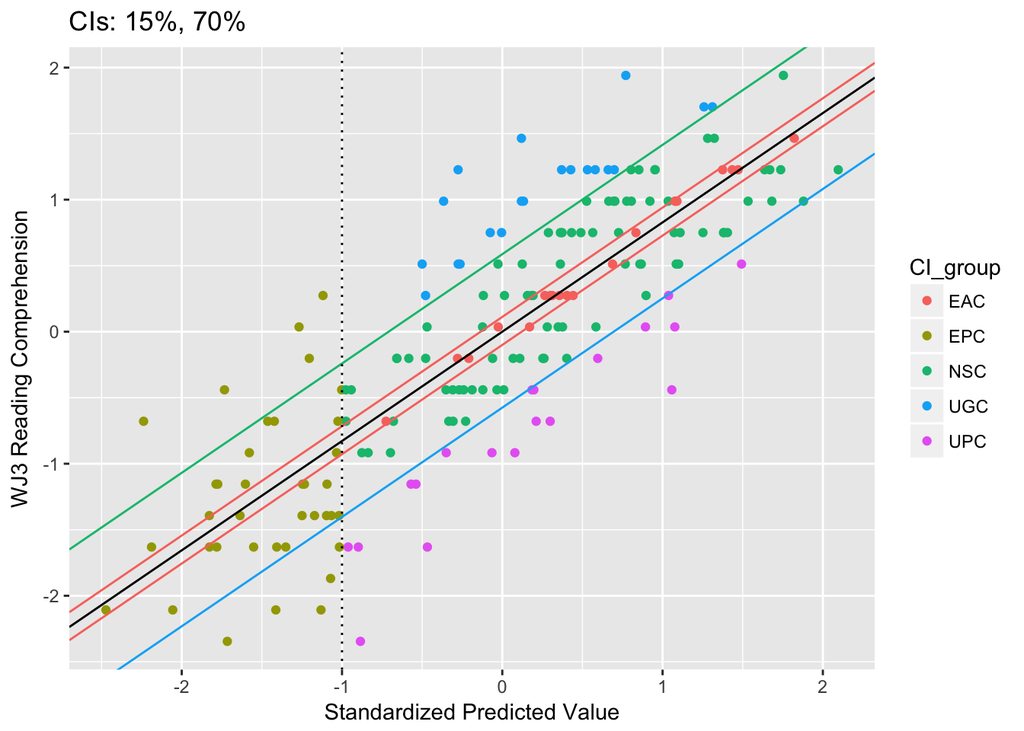

```r
print(p1)
```

```r
RLM.WV <- data.frame(table(rlmwv.cc$CI_group, rlmwv.cc$handedness))
names(RLM.WV) <- c("Group", "handedness", "rlm.wasi.vocab")
RLM.WV.r <- RLM.WV[RLM.WV$handedness == "right",]
RLM.WV.r <- RLM.WV.r[,-2]
```

## Robust Model with PPVT

Run model, get groups.

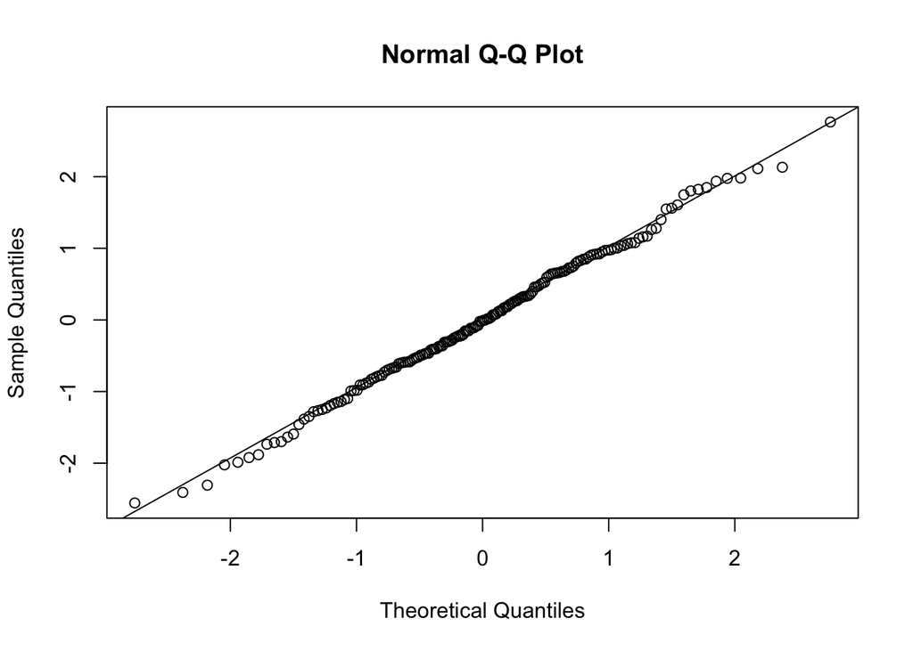

```r
model.data.rlmpp <- data[, c(1, 3, 19, 8, 6, 21, 12)]
rlmpp.cc <- model.data.rlmpp[complete.cases(model.data.rlmpp),]

# center and scale predictors
rlmpp.cc$wasi.matr.cs <- scale(rlmpp.cc$wasi.matr.raw)
rlmpp.cc$ppvt.cs <- scale(rlmpp.cc$ppvt.raw)
rlmpp.cc$wj3.rcomp.cs <- scale(rlmpp.cc$wj3.rcomp.raw)

# center age
rlmpp.cc$age.c <- rlmpp.cc$age.beh - mean(rlmpp.cc$age.beh, na.rm = TRUE)
# composite has already been scaled

### Run regression
m1 <- rlm(wj3.rcomp.cs ~ age.c + decoding.comp + wasi.matr.cs + ppvt.cs, data = rlmpp.cc, method = "MM")

#standardize predicted values
rlmpp.cc$Pred <- predict(m1)
rlmpp.cc$stdPred <- scale(rlmpp.cc$Pred)

#obtained residuals
rlmpp.cc$resid <- resid <- residuals(m1)
qqnorm(scale(resid)); qqline(scale(resid))
```

```r
#create the range of SD (z value) bins
my.bin <- c(range(scale(resid))+.1, ci2z(ci.to.use), -ci2z(ci.to.use))
#we could also manually specify in terms of SDs
# my.bin <- c(-3, -1, -.25, .25, 1, 3)
my.bin <- sort(my.bin)
# names for each bin specified above
grouping <- c("UPC", "NSC", "EAC", "NSC", "UGC")

rlmpp.cc$CI_group <- grouping[findInterval(scale(resid), vec=my.bin, all.inside=T)]
#those with Standardized Predicted Value below -1 should be "EPC"
rlmpp.cc$CI_group[rlmpp.cc$stdPred < -1] <- "EPC"

### there are five groups c("EAC", "NSC", "UGC", "UPC", "EPC")
### so the argument n = 5
my.col <- gg_color_hue(n=5)

## unscale the z value for each CI, so I can add that value to intercept
unscale.ci <- my.bin[-c(1,length(my.bin))]*sd(resid)+mean(resid)

## create plot
m2 <- lm(wj3.rcomp.cs ~ stdPred, data=rlmpp.cc)

p1 <- ggplot(rlmpp.cc, aes(x=stdPred, y=wj3.rcomp.cs)) + geom_point(aes(color=CI_group)) +
  geom_abline(intercept = coef(m2)[1], slope = coef(m2)[2]) +
  geom_abline(intercept = coef(m2)[1] + unscale.ci[2], slope = coef(m2)[2], color=my.col[1]) +
  geom_abline(intercept = coef(m2)[1] + unscale.ci[3], slope = coef(m2)[2], color=my.col[1]) +
  geom_abline(intercept = coef(m2)[1] + unscale.ci[1], slope = coef(m2)[2], color=my.col[4]) +
  geom_abline(intercept = coef(m2)[1] + unscale.ci[4], slope = coef(m2)[2], color=my.col[3]) +
  geom_vline(xintercept = -1, lty="dotted") +
  xlab("Standardized Predicted Value")+ylab("WJ3 Reading Comprehension") +
  ggtitle(ci.title)
```

## Group Differences RLM2

Robust Model with PPVT

```r
# take away NSC group
rlmpp.cc2 <- subset(rlmpp.cc, CI_group != "NSC")
rlmpp.cc2$CI_group <- as.factor(rlmpp.cc2$CI_group)
```

### Reading Comprehension

```r
a1 <- aov(wj3.rcomp.cs ~ CI_group, data = rlmpp.cc2)
summary(a1)
```

```
##             Df Sum Sq Mean Sq F value Pr(>F)
## CI_group     3  79.86  26.619   81.32 <2e-16 ***
## Residuals   83  27.17   0.327
## ---
## Signif. codes:  0 '***' 0.001 '**' 0.01 '*' 0.05 '.' 0.1 ' ' 1
```

```r
pairwise.t.test(rlmpp.cc2$wj3.rcomp.cs, rlmpp.cc2$CI_group, p.adjust.method = "bonferroni")
```

```
##
##  Pairwise comparisons using t tests with pooled SD
##
## data:  rlmpp.cc2$wj3.rcomp.cs and rlmpp.cc2$CI_group
##
##     EAC     EPC     UGC
## EPC < 2e-16 -       -
## UGC 0.00068 < 2e-16 -
## UPC 4.1e-07 0.00024 8.6e-14
##
## P value adjustment method: bonferroni
```

```r
aggregate(rlmpp.cc2$wj3.rcomp.cs, list(rlmpp.cc2$CI_group), mean)
```

```
##   Group.1         V1
## 1     EAC  0.3870984
## 2     EPC -1.3774136
## 3     UGC  1.1634837
## 4     UPC -0.6598454
```

### Age

```r
a1 <- aov(age.c ~ CI_group, data = rlmpp.cc2)
summary(a1)
```

```
##             Df Sum Sq Mean Sq F value  Pr(>F)
## CI_group     3  109.0   36.32   4.901 0.00348 **
## Residuals   83  615.1    7.41
## ---
## Signif. codes:  0 '***' 0.001 '**' 0.01 '*' 0.05 '.' 0.1 ' ' 1
```

```r
pairwise.t.test(rlmpp.cc2$age.c, rlmpp.cc2$CI_group, p.adjust.method = "bonferroni")
```

```
##
##  Pairwise comparisons using t tests with pooled SD
##
## data:  rlmpp.cc2$age.c and rlmpp.cc2$CI_group
##
##     EAC    EPC    UGC
## EPC 0.1948 -      -
## UGC 1.0000 0.0086 -
## UPC 1.0000 0.0225 1.0000
##
## P value adjustment method: bonferroni
```

```r
aggregate(rlmpp.cc2$age.c, list(rlmpp.cc2$CI_group), mean)
```

```
##   Group.1          x
## 1     EAC -0.1327044
## 2     EPC -1.7948256
## 3     UGC  1.0431744
## 4     UPC  0.5496744
```

### Matrix Reasoning

```r
a1 <- aov(wasi.matr.cs ~ CI_group, data = rlmpp.cc2)
summary(a1)
```

```
##             Df Sum Sq Mean Sq F value   Pr(>F)
## CI_group     3  41.51  13.836    24.2 2.38e-11 ***
## Residuals   83  47.45   0.572
## ---
## Signif. codes:  0 '***' 0.001 '**' 0.01 '*' 0.05 '.' 0.1 ' ' 1
```

```r
pairwise.t.test(rlmpp.cc2$wasi.matr.cs, rlmpp.cc2$CI_group, p.adjust.method = "bonferroni")
```

```
##
##  Pairwise comparisons using t tests with pooled SD
##
## data:  rlmpp.cc2$wasi.matr.cs and rlmpp.cc2$CI_group
##
##     EAC     EPC     UGC
## EPC 1.1e-09 -       -
## UGC 1       7.7e-08 -
## UPC 1       6.9e-07 1
##
## P value adjustment method: bonferroni
```

```r
aggregate(rlmpp.cc2$wasi.matr.cs, list(rlmpp.cc2$CI_group), mean)
```

```
##   Group.1          V1
## 1     EAC  0.29888386
## 2     EPC -1.24438201
## 3     UGC  0.26497459
## 4     UPC  0.02208962
```

### Decoding

```r
a1 <- aov(decoding.comp ~ CI_group, data = rlmpp.cc2)
summary(a1)
```

```
##             Df Sum Sq Mean Sq F value   Pr(>F)
## CI_group     3  44.85  14.950   25.99 5.96e-12 ***
## Residuals   83  47.74   0.575
## ---
## Signif. codes:  0 '***' 0.001 '**' 0.01 '*' 0.05 '.' 0.1 ' ' 1
```

```r
pairwise.t.test(rlmpp.cc2$decoding.comp, rlmpp.cc2$CI_group, p.adjust.method = "bonferroni")
```

```
##
##  Pairwise comparisons using t tests with pooled SD
##
## data:  rlmpp.cc2$decoding.comp and rlmpp.cc2$CI_group
##
##     EAC     EPC     UGC
## EPC 3.0e-11 -       -
## UGC 1.0     5.4e-07 -
## UPC 0.3     1.1e-06 1.0
##
## P value adjustment method: bonferroni
```

```r
aggregate(rlmpp.cc2$decoding.comp, list(rlmpp.cc2$CI_group), mean)
```

```
##   Group.1           x
## 1     EAC  0.45048743
## 2     EPC -1.26517302
## 3     UGC  0.14049041
## 4     UPC -0.01710787
```

### PPVT

```r
a1 <- aov(ppvt.cs ~ CI_group, data = rlmpp.cc2)
summary(a1)
```

```
##             Df Sum Sq Mean Sq F value Pr(>F)
## CI_group     3  85.58  28.526   71.06 <2e-16 ***
## Residuals   83  33.32   0.401
## ---
## Signif. codes:  0 '***' 0.001 '**' 0.01 '*' 0.05 '.' 0.1 ' ' 1
```

```r
pairwise.t.test(rlmpp.cc2$ppvt.cs, rlmpp.cc2$CI_group, p.adjust.method = "bonferroni")
```

```
##
##  Pairwise comparisons using t tests with pooled SD
##
## data:  rlmpp.cc2$ppvt.cs and rlmpp.cc2$CI_group
##
##     EAC    EPC    UGC
## EPC <2e-16 -      -
## UGC 1      <2e-16 -
## UPC 1      <2e-16 1
##
## P value adjustment method: bonferroni
```

```r
aggregate(rlmpp.cc2$ppvt.cs, list(rlmpp.cc2$CI_group), mean)
```

```
##   Group.1         V1
## 1     EAC  0.4259729
## 2     EPC -1.7037212
## 3     UGC  0.4470100
## 4     UPC  0.2758849
```

Show group sizes, plot.

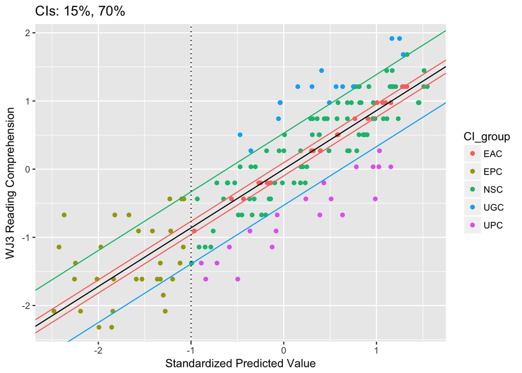

```r
print(p1)
```

```r
RLM.PP <- data.frame(table(rlmpp.cc$CI_group, rlmpp.cc$handedness))
names(RLM.PP) <- c("Group", "handedness", "rlm.ppvt")
RLM.PP.r <- RLM.PP[RLM.PP$handedness == "right",]
RLM.PP.r <- RLM.PP.r[,-2]
```

## Robust Model with Vocab Composite

Run model, get groups.

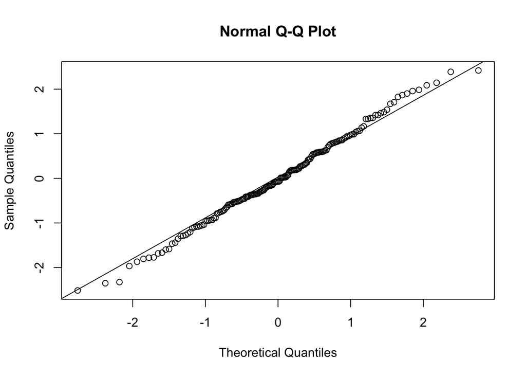

```r
model.data.rlmvc <- data[, c(1, 3, 19, 8, 22, 21, 12)]
rlmvc.cc <- model.data.rlmvc[complete.cases(model.data.rlmvc),]

# center and scale predictors
rlmvc.cc$wasi.matr.cs <- scale(rlmvc.cc$wasi.matr.raw)
rlmvc.cc$wj3.rcomp.cs <- scale(rlmvc.cc$wj3.rcomp.raw)

# center age
rlmvc.cc$age.c <- rlmvc.cc$age.beh - mean(rlmvc.cc$age.beh, na.rm = TRUE)
# composites have already been scaled

### Run regression
m1 <- rlm(wj3.rcomp.cs ~ age.c + decoding.comp + wasi.matr.cs + vocab.comp, data = rlmvc.cc, method = "MM")

#standardize predicted values
rlmvc.cc$Pred <- predict(m1)
rlmvc.cc$stdPred <- scale(rlmvc.cc$Pred)

#obtained residuals
rlmvc.cc$resid <- resid <- residuals(m1)
qqnorm(scale(resid)); qqline(scale(resid))
```

```r
#create the range of SD (z value) bins
my.bin <- c(range(scale(resid))+.1, ci2z(ci.to.use), -ci2z(ci.to.use))
#we could also manually specify in terms of SDs
# my.bin <- c(-3, -1, -.25, .25, 1, 3)
my.bin <- sort(my.bin)
# names for each bin specified above
grouping <- c("UPC", "NSC", "EAC", "NSC", "UGC")

rlmvc.cc$CI_group <- grouping[findInterval(scale(resid), vec=my.bin, all.inside=T)]
#those with Standardized Predicted Value below -1 should be "EPC"
rlmvc.cc$CI_group[rlmvc.cc$stdPred < -1] <- "EPC"

### there are five groups c("EAC", "NSC", "UGC", "UPC", "EPC")
### so the argument n = 5
my.col <- gg_color_hue(n=5)

## unscale the z value for each CI, so I can add that value to intercept
unscale.ci <- my.bin[-c(1,length(my.bin))]*sd(resid)+mean(resid)

## create plot
m2 <- lm(wj3.rcomp.cs ~ stdPred, data=rlmvc.cc)

p1 <- ggplot(rlmvc.cc, aes(x=stdPred, y=wj3.rcomp.cs)) + geom_point(aes(color=CI_group)) +
  geom_abline(intercept = coef(m2)[1], slope = coef(m2)[2]) +
  geom_abline(intercept = coef(m2)[1] + unscale.ci[2], slope = coef(m2)[2], color=my.col[1]) +
  geom_abline(intercept = coef(m2)[1] + unscale.ci[3], slope = coef(m2)[2], color=my.col[1]) +
  geom_abline(intercept = coef(m2)[1] + unscale.ci[1], slope = coef(m2)[2], color=my.col[4]) +
  geom_abline(intercept = coef(m2)[1] + unscale.ci[4], slope = coef(m2)[2], color=my.col[3]) +
  geom_vline(xintercept = -1, lty="dotted") +
  xlab("Standardized Predicted Value")+ylab("WJ3 Reading Comprehension") +
  ggtitle(ci.title)
```

## Group Differences RLM3

Robust Model with Vocab Composite

```r
# take away NSC group
rlmvc.cc2 <- subset(rlmvc.cc, CI_group != "NSC")
rlmvc.cc2$CI_group <- as.factor(rlmvc.cc2$CI_group)
```

### Reading Comprehension

```r
a1 <- aov(wj3.rcomp.cs ~ CI_group, data = rlmvc.cc2)
summary(a1)
```

```
##             Df Sum Sq Mean Sq F value Pr(>F)
## CI_group     3  74.13   24.71   63.29 <2e-16 ***
## Residuals   91  35.53    0.39
## ---
## Signif. codes:  0 '***' 0.001 '**' 0.01 '*' 0.05 '.' 0.1 ' ' 1
```

```r
pairwise.t.test(rlmvc.cc2$wj3.rcomp.cs, rlmvc.cc2$CI_group, p.adjust.method = "bonferroni")
```

```
##
##  Pairwise comparisons using t tests with pooled SD
##
## data:  rlmvc.cc2$wj3.rcomp.cs and rlmvc.cc2$CI_group
##
##     EAC     EPC     UGC
## EPC 7.1e-15 -       -
## UGC 0.04818 < 2e-16 -
## UPC 0.00026 7.6e-05 4.8e-09
##
## P value adjustment method: bonferroni
```

```r
aggregate(rlmvc.cc2$wj3.rcomp.cs, list(rlmvc.cc2$CI_group), mean)
```

```
##   Group.1         V1
## 1     EAC  0.3988618
## 2     EPC -1.2721620
## 3     UGC  0.9491281
## 4     UPC -0.4611056
```

### Age

```r
a1 <- aov(age.c ~ CI_group, data = rlmvc.cc2)
summary(a1)
```

```
##             Df Sum Sq Mean Sq F value   Pr(>F)
## CI_group     3  132.2   44.08    6.16 0.000735 ***
## Residuals   91  651.1    7.15
## ---
## Signif. codes:  0 '***' 0.001 '**' 0.01 '*' 0.05 '.' 0.1 ' ' 1
```

```r
pairwise.t.test(rlmvc.cc2$age.c, rlmvc.cc2$CI_group, p.adjust.method = "bonferroni")
```

```
##
##  Pairwise comparisons using t tests with pooled SD
##
## data:  rlmvc.cc2$age.c and rlmvc.cc2$CI_group
##
##     EAC   EPC   UGC
## EPC 0.002 -     -
## UGC 1.000 0.019 -
## UPC 1.000 0.068 1.000
##
## P value adjustment method: bonferroni
```

```r
aggregate(rlmvc.cc2$age.c, list(rlmvc.cc2$CI_group), mean)
```

```
##   Group.1          x
## 1     EAC  1.0575078
## 2     EPC -1.7022817
## 3     UGC  0.6159152
## 4     UPC  0.2406130
```

### Matrix Reasoning

```r
a1 <- aov(wasi.matr.cs ~ CI_group, data = rlmvc.cc2)
summary(a1)
```

```
##             Df Sum Sq Mean Sq F value   Pr(>F)
## CI_group     3  42.34  14.114   22.57 5.19e-11 ***
## Residuals   91  56.91   0.625
## ---
## Signif. codes:  0 '***' 0.001 '**' 0.01 '*' 0.05 '.' 0.1 ' ' 1
```

```r
pairwise.t.test(rlmvc.cc2$wasi.matr.cs, rlmvc.cc2$CI_group, p.adjust.method = "bonferroni")
```

```
##
##  Pairwise comparisons using t tests with pooled SD
##
## data:  rlmvc.cc2$wasi.matr.cs and rlmvc.cc2$CI_group
##
##     EAC     EPC     UGC
## EPC 3.6e-09 -       -
## UGC 1       1.0e-06 -
## UPC 1       1.5e-06 1
##
## P value adjustment method: bonferroni
```

```r
aggregate(rlmvc.cc2$wasi.matr.cs, list(rlmvc.cc2$CI_group), mean)
```

```
##   Group.1         V1
## 1     EAC  0.3473820
## 2     EPC -1.1653987
## 3     UGC  0.1175087
## 4     UPC  0.0741364
```

### Decoding

```r
a1 <- aov(decoding.comp ~ CI_group, data = rlmvc.cc2)
summary(a1)
```

```
##             Df Sum Sq Mean Sq F value   Pr(>F)
## CI_group     3  49.26  16.421    23.1 3.32e-11 ***
## Residuals   91  64.69   0.711
## ---
## Signif. codes:  0 '***' 0.001 '**' 0.01 '*' 0.05 '.' 0.1 ' ' 1
```

```r
pairwise.t.test(rlmvc.cc2$decoding.comp, rlmvc.cc2$CI_group, p.adjust.method = "bonferroni")
```

```
##
##  Pairwise comparisons using t tests with pooled SD
##
## data:  rlmvc.cc2$decoding.comp and rlmvc.cc2$CI_group
##
##     EAC     EPC     UGC
## EPC 4.4e-09 -       -
## UGC 1       8.4e-06 -
## UPC 1       7.0e-08 1
##
## P value adjustment method: bonferroni
```

```r
aggregate(rlmvc.cc2$decoding.comp, list(rlmvc.cc2$CI_group), mean)
```

```
##   Group.1           x
## 1     EAC  0.43647382
## 2     EPC -1.16616514
## 3     UGC  0.08033825
## 4     UPC  0.32000612
```

### Vocab Composite

```r
a1 <- aov(vocab.comp ~ CI_group, data = rlmvc.cc2)
summary(a1)
```

```
##             Df Sum Sq Mean Sq F value Pr(>F)
## CI_group     3  70.30  23.435   62.63 <2e-16 ***
## Residuals   91  34.05   0.374
## ---
## Signif. codes:  0 '***' 0.001 '**' 0.01 '*' 0.05 '.' 0.1 ' ' 1
```

```r
pairwise.t.test(rlmvc.cc2$vocab.comp, rlmvc.cc2$CI_group, p.adjust.method = "bonferroni")
```

```
##
##  Pairwise comparisons using t tests with pooled SD
##
## data:  rlmvc.cc2$vocab.comp and rlmvc.cc2$CI_group
##
##     EAC     EPC     UGC
## EPC < 2e-16 -       -
## UGC 0.53    4.6e-13 -
## UPC 1.00    2.9e-16 1.00
##
## P value adjustment method: bonferroni
```

```r
aggregate(rlmvc.cc2$vocab.comp, list(rlmvc.cc2$CI_group), mean)
```

```
##   Group.1          x
## 1     EAC  0.4479751
## 2     EPC -1.4376554
## 3     UGC  0.1054459
## 4     UPC  0.3403603
```

Show group sizes, plot.

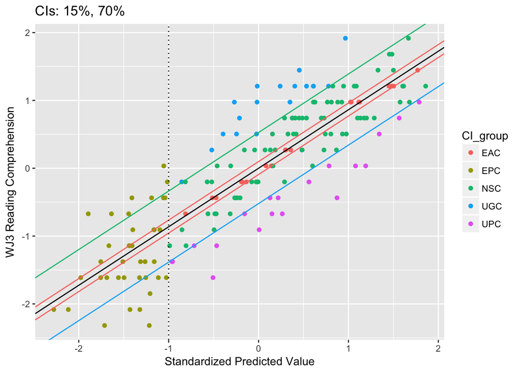

```r
print(p1)
```

```r
RLM.VC <- data.frame(table(rlmvc.cc$CI_group, rlmvc.cc$handedness))
names(RLM.VC) <- c("Group", "handedness", "rlm.ppvt")
RLM.VC.r <- RLM.VC[RLM.VC$handedness == "right",]
RLM.VC.r <- RLM.VC.r[,-2]
```

## Robust Model with Oral Comprehension

Run model, get groups.

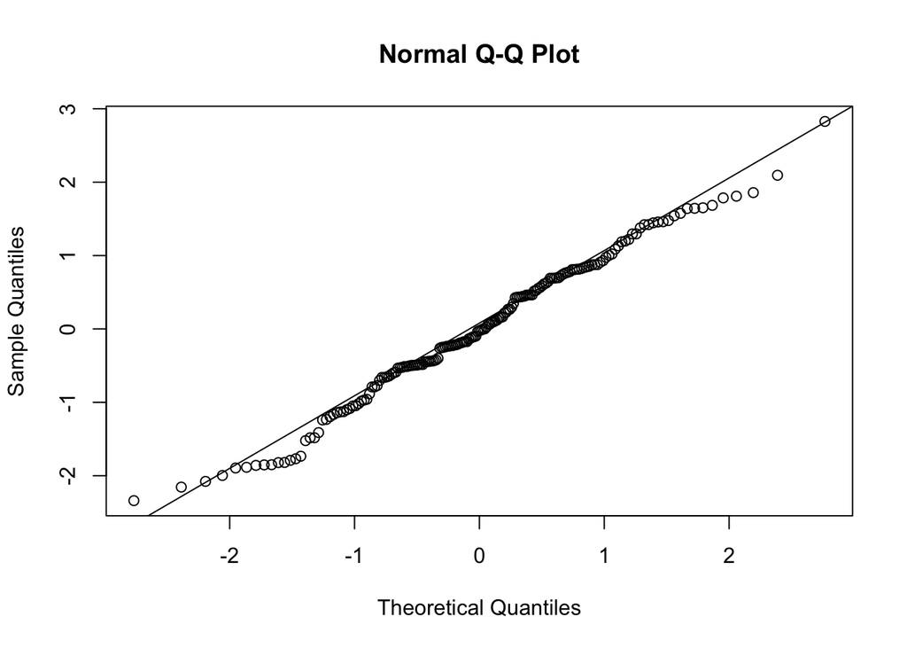

```r
model.data.rlmoc <- data[, c(1, 3, 19, 8, 13, 21, 12)]
rlmoc.cc <- model.data.rlmoc[complete.cases(model.data.rlmoc),]

# center and scale predictors
rlmoc.cc$wasi.matr.cs <- scale(rlmoc.cc$wasi.matr.raw)
rlmoc.cc$wj3.rcomp.cs <- scale(rlmoc.cc$wj3.rcomp.raw)
rlmoc.cc$wj3.oralcomp.cs <- scale(rlmoc.cc$wj3.oralcomp.raw)

# center age
rlmoc.cc$age.c <- rlmoc.cc$age.beh - mean(rlmoc.cc$age.beh, na.rm = TRUE)
# composites have already been scaled

### Run regression
m1 <- rlm(wj3.rcomp.cs ~ age.c + decoding.comp + wasi.matr.cs + wj3.oralcomp.cs, data = rlmoc.cc, method = "MM")

#standardize predicted values
rlmoc.cc$Pred <- predict(m1)
rlmoc.cc$stdPred <- scale(rlmoc.cc$Pred)

#obtained residuals
rlmoc.cc$resid <- resid <- residuals(m1)
qqnorm(scale(resid)); qqline(scale(resid))
```

```r
#create the range of SD (z value) bins
my.bin <- c(range(scale(resid))+.1, ci2z(ci.to.use), -ci2z(ci.to.use))
#we could also manually specify in terms of SDs
# my.bin <- c(-3, -1, -.25, .25, 1, 3)
my.bin <- sort(my.bin)
# names for each bin specified above
grouping <- c("UPC", "NSC", "EAC", "NSC", "UGC")

rlmoc.cc$CI_group <- grouping[findInterval(scale(resid), vec=my.bin, all.inside=T)]
#those with Standardized Predicted Value below -1 should be "EPC"
rlmoc.cc$CI_group[rlmoc.cc$stdPred < -1] <- "EPC"

### there are five groups c("EAC", "NSC", "UGC", "UPC", "EPC")
### so the argument n = 5
my.col <- gg_color_hue(n=5)

## unscale the z value for each CI, so I can add that value to intercept
unscale.ci <- my.bin[-c(1,length(my.bin))]*sd(resid)+mean(resid)

## create plot
m2 <- lm(wj3.rcomp.cs ~ stdPred, data=rlmoc.cc)

p1 <- ggplot(rlmoc.cc, aes(x=stdPred, y=wj3.rcomp.cs)) + geom_point(aes(color=CI_group)) +
  geom_abline(intercept = coef(m2)[1], slope = coef(m2)[2]) +
  geom_abline(intercept = coef(m2)[1] + unscale.ci[2], slope = coef(m2)[2], color=my.col[1]) +
  geom_abline(intercept = coef(m2)[1] + unscale.ci[3], slope = coef(m2)[2], color=my.col[1]) +
  geom_abline(intercept = coef(m2)[1] + unscale.ci[1], slope = coef(m2)[2], color=my.col[4]) +
  geom_abline(intercept = coef(m2)[1] + unscale.ci[4], slope = coef(m2)[2], color=my.col[3]) +
  geom_vline(xintercept = -1, lty="dotted") +
  xlab("Standardized Predicted Value")+ylab("WJ3 Reading Comprehension") +
  ggtitle(ci.title)
```

## Group Differences RLM4

Robust Model with Oral Comprehension

```r
# take away NSC group
rlmoc.cc2 <- subset(rlmoc.cc, CI_group != "NSC")
rlmoc.cc2$CI_group <- as.factor(rlmoc.cc2$CI_group)
```

### Reading Comprehension

```r
a1 <- aov(wj3.rcomp.cs ~ CI_group, data = rlmoc.cc2)
summary(a1)
```

```
##             Df Sum Sq Mean Sq F value Pr(>F)
## CI_group     3  80.42  26.806   73.79 <2e-16 ***
## Residuals   90  32.69   0.363
## ---
## Signif. codes:  0 '***' 0.001 '**' 0.01 '*' 0.05 '.' 0.1 ' ' 1
```

```r
pairwise.t.test(rlmoc.cc2$wj3.rcomp.cs, rlmoc.cc2$CI_group, p.adjust.method = "bonferroni")
```

```
##
##  Pairwise comparisons using t tests with pooled SD
##
## data:  rlmoc.cc2$wj3.rcomp.cs and rlmoc.cc2$CI_group
##
##     EAC     EPC     UGC
## EPC 1.5e-14 -       -
## UGC 0.0033  < 2e-16 -
## UPC 2.6e-06 0.0010  6.2e-14
##
## P value adjustment method: bonferroni
```

```r
aggregate(rlmoc.cc2$wj3.rcomp.cs, list(rlmoc.cc2$CI_group), mean)
```

```
##   Group.1         V1
## 1     EAC  0.3722220
## 2     EPC -1.2969434
## 3     UGC  1.0918212
## 4     UPC -0.6625639
```

### Age

```r
a1 <- aov(age.c ~ CI_group, data = rlmoc.cc2)
summary(a1)
```

```
##             Df Sum Sq Mean Sq F value  Pr(>F)
## CI_group     3  102.8   34.28   5.047 0.00281 **
## Residuals   90  611.3    6.79
## ---
## Signif. codes:  0 '***' 0.001 '**' 0.01 '*' 0.05 '.' 0.1 ' ' 1
```

```r
pairwise.t.test(rlmoc.cc2$age.c, rlmoc.cc2$CI_group, p.adjust.method = "bonferroni")
```

```
##
##  Pairwise comparisons using t tests with pooled SD
##
## data:  rlmoc.cc2$age.c and rlmoc.cc2$CI_group
##
##     EAC    EPC    UGC
## EPC 0.0082 -      -
## UGC 1.0000 0.0849 -
## UPC 1.0000 0.0299 1.0000
##
## P value adjustment method: bonferroni
```

```r
aggregate(rlmoc.cc2$age.c, list(rlmoc.cc2$CI_group), mean)
```

```
##   Group.1          x
## 1     EAC  0.8668550
## 2     EPC -1.6298434
## 3     UGC  0.2616698
## 4     UPC  0.3840531
```

### Matrix Reasoning

```r
a1 <- aov(wasi.matr.cs ~ CI_group, data = rlmoc.cc2)
summary(a1)
```

```
##             Df Sum Sq Mean Sq F value   Pr(>F)
## CI_group     3  45.95  15.316   23.04 3.72e-11 ***
## Residuals   90  59.82   0.665
## ---
## Signif. codes:  0 '***' 0.001 '**' 0.01 '*' 0.05 '.' 0.1 ' ' 1
```

```r
pairwise.t.test(rlmoc.cc2$wasi.matr.cs, rlmoc.cc2$CI_group, p.adjust.method = "bonferroni")
```

```
##
##  Pairwise comparisons using t tests with pooled SD
##
## data:  rlmoc.cc2$wasi.matr.cs and rlmoc.cc2$CI_group
##
##     EAC     EPC     UGC
## EPC 3.0e-08 -       -
## UGC 1       1.2e-07 -
## UPC 1       9.5e-08 1
##
## P value adjustment method: bonferroni
```

```r
aggregate(rlmoc.cc2$wasi.matr.cs, list(rlmoc.cc2$CI_group), mean)
```

```
##   Group.1          V1
## 1     EAC  0.23594588
## 2     EPC -1.29416333
## 3     UGC  0.16351712
## 4     UPC  0.06526594
```

### Decoding

```r
a1 <- aov(decoding.comp ~ CI_group, data = rlmoc.cc2)
summary(a1)
```

```
##             Df Sum Sq Mean Sq F value   Pr(>F)
## CI_group     3  56.96  18.985   38.27 4.91e-16 ***
## Residuals   90  44.65   0.496
## ---
## Signif. codes:  0 '***' 0.001 '**' 0.01 '*' 0.05 '.' 0.1 ' ' 1
```

```r
pairwise.t.test(rlmoc.cc2$decoding.comp, rlmoc.cc2$CI_group, p.adjust.method = "bonferroni")
```

```
##
##  Pairwise comparisons using t tests with pooled SD
##
## data:  rlmoc.cc2$decoding.comp and rlmoc.cc2$CI_group
##
##     EAC     EPC     UGC
## EPC 3.3e-13 -       -
## UGC 1.00    1.2e-10 -
## UPC 0.46    2.3e-10 1.00
##
## P value adjustment method: bonferroni
```

```r
aggregate(rlmoc.cc2$decoding.comp, list(rlmoc.cc2$CI_group), mean)
```

```
##   Group.1          x
## 1     EAC  0.5227211
## 2     EPC -1.2958423
## 3     UGC  0.2715307
## 4     UPC  0.1264724
```

### Oral Comprehension

```r
a1 <- aov(wj3.oralcomp.cs ~ CI_group, data = rlmoc.cc2)
summary(a1)
```

```
##             Df Sum Sq Mean Sq F value Pr(>F)
## CI_group     3  65.05  21.683   43.07 <2e-16 ***
## Residuals   90  45.31   0.503
## ---
## Signif. codes:  0 '***' 0.001 '**' 0.01 '*' 0.05 '.' 0.1 ' ' 1
```

```r
pairwise.t.test(rlmoc.cc2$wj3.oralcomp.cs, rlmoc.cc2$CI_group, p.adjust.method = "bonferroni")
```

```
##
##  Pairwise comparisons using t tests with pooled SD
##
## data:  rlmoc.cc2$wj3.oralcomp.cs and rlmoc.cc2$CI_group
##
##     EAC     EPC     UGC
## EPC 2.2e-12 -       -
## UGC 1       1.6e-12 -
## UPC 1       8.3e-13 1
##
## P value adjustment method: bonferroni
```

```r
aggregate(rlmoc.cc2$wj3.oralcomp.cs, list(rlmoc.cc2$CI_group), mean)
```

```
##   Group.1         V1
## 1     EAC  0.3090389
## 2     EPC -1.4410385
## 3     UGC  0.3237313
## 4     UPC  0.2176904
```

Show group sizes, plot.

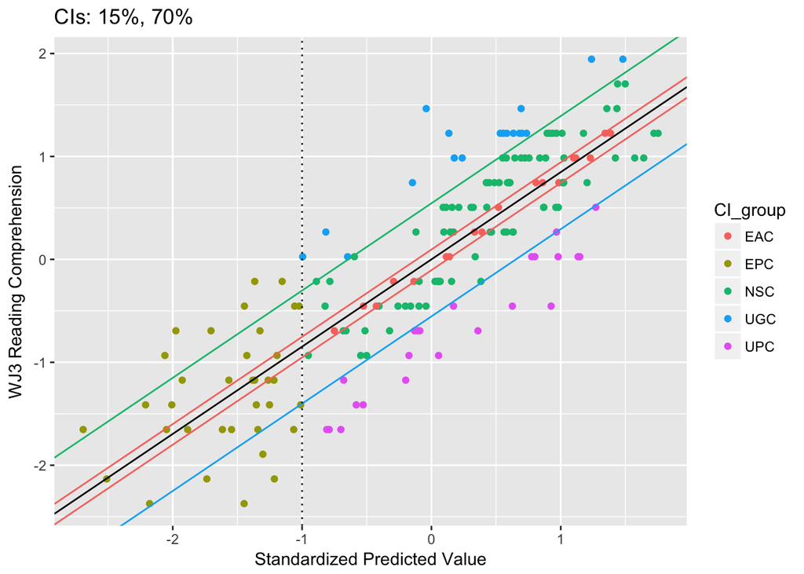

```r
print(p1)
```

```r
RLM.OC <- data.frame(table(rlmoc.cc$CI_group, rlmoc.cc$handedness))
names(RLM.OC) <- c("Group", "handedness", "rlm.ppvt")
RLM.OC.r <- RLM.OC[RLM.OC$handedness == "right",]
RLM.OC.r <- RLM.OC.r[,-2]
```

## Group Sizes

Across analyses

```r
group.sizes <- cbind(LM.WASI.Vocab.r, LM.PPVT.r[,2], LM.VC.r[,2], LM.OC.r[,2], RLM.WV.r[,2], RLM.PP.r[,2], RLM.VC.r[,2], RLM.OC.r[,2])
names(group.sizes) <- c("group", "LM1 (WASI Vocab)", "LM2 (PPVT)", "LM3 (Vocab Composite)", "LM4 (Oral Comp)", "RLM1 (WASI Vocab)", "RLM2 (PPVT)", "RLM3 (Vocab Composite)", "RLM4 (Oral Comp)")
gs <- xtable(group.sizes)
print(gs, type ="html", include.rownames = FALSE)
```

| group | LM1 (WASI Vocab) | LM2 (PPVT) | LM3 (Vocab Composite) | LM4 (Oral Comp) | RLM1 (WASI Vocab) | RLM2 (PPVT) | RLM3 (Vocab Composite) | RLM4 (Oral Comp) |
| --- | --- | --- | --- | --- | --- | --- | --- | --- |
| EAC | 20 | 20 | 17 | 17 | 20 | 22 | 20 | 18 |
| EPC | 37 | 35 | 39 | 36 | 37 | 30 | 38 | 35 |
| NSC | 79 | 80 | 78 | 85 | 83 | 85 | 77 | 83 |
| UGC | 23 | 19 | 20 | 18 | 20 | 15 | 18 | 18 |
| UPC | 20 | 18 | 18 | 21 | 19 | 20 | 19 | 23 |